```python
# temp time check - remove before submission
import datetime
begin_time = datetime.datetime.now()
```

# Phase 2 Data Prep

## Environment setup

The code in section 1.1 is a repeat of the code in the first EDA notebook in order to bring in the data.

```python
# set the data directory
DATA_DIR = "../data/home-credit-default-risk"  # data folder will be present in the level as the code folder

# set the directory for storing model objects
MODEL_DIR = "../output/models"

# set the results folder for storing model results
REPORT_DIR = "../output/reports"

# set the submission folder
SUBMISSION_DIR = "../output/submissions"
```

```python
# data manipulation
import numpy as np
import pandas as pd

import os
import zipfile

# plotting
import matplotlib.pyplot as plt
import seaborn as sns
from pandas.plotting import scatter_matrix

# splitting
from sklearn.model_selection import train_test_split

# preprocessing
from sklearn.impute import SimpleImputer
from sklearn.preprocessing import MinMaxScaler, StandardScaler, OneHotEncoder, LabelEncoder

# pipelines
from sklearn.compose import ColumnTransformer
from sklearn.base import BaseEstimator, TransformerMixin
from sklearn.pipeline import Pipeline, FeatureUnion, make_pipeline

# models
from sklearn.linear_model import LogisticRegression
from sklearn.ensemble import RandomForestClassifier
from xgboost import XGBClassifier

# tuning
from sklearn.model_selection import GridSearchCV, cross_val_score, cross_validate
from skopt import BayesSearchCV

# model evaluation
from sklearn.metrics import accuracy_score, f1_score, roc_auc_score, classification_report, confusion_matrix, plot_confusion_matrix

# do not show warnings
import warnings
warnings.filterwarnings('ignore')

# set pandas display options
pd.set_option('display.max_rows', 500)
pd.set_option('display.max_columns', 500)
pd.set_option('display.width', 1000)

def load_data(in_path, name):
    df = pd.read_csv(in_path)
    print(f"{name}: shape is {df.shape}")
    print(df.info())
    display(df.head(5))
    return df

datasets={}  # data will be stored in a dictionary
```

## Data Load

```python
%%time
ds_names = ("application_train", "application_test", "bureau","bureau_balance","credit_card_balance","installments_payments",
            "previous_application","POS_CASH_balance")

for ds_name in ds_names:
    datasets[ds_name] = load_data(os.path.join(DATA_DIR, f'{ds_name}.csv'), ds_name)
```

```
application_train: shape is (307511, 122)
<class 'pandas.core.frame.DataFrame'>
RangeIndex: 307511 entries, 0 to 307510
Columns: 122 entries, SK_ID_CURR to AMT_REQ_CREDIT_BUREAU_YEAR
dtypes: float64(65), int64(41), object(16)
memory usage: 286.2+ MB
None
```

|  | SK_ID_CURR | TARGET | NAME_CONTRACT_TYPE | CODE_GENDER | FLAG_OWN_CAR | FLAG_OWN_REALTY | CNT_CHILDREN | AMT_INCOME_TOTAL | AMT_CREDIT | AMT_ANNUITY | AMT_GOODS_PRICE | NAME_TYPE_SUITE | NAME_INCOME_TYPE | NAME_EDUCATION_TYPE | NAME_FAMILY_STATUS | NAME_HOUSING_TYPE | REGION_POPULATION_RELATIVE | DAYS_BIRTH | DAYS_EMPLOYED | DAYS_REGISTRATION | DAYS_ID_PUBLISH | OWN_CAR_AGE | FLAG_MOBIL | FLAG_EMP_PHONE | FLAG_WORK_PHONE | FLAG_CONT_MOBILE | FLAG_PHONE | FLAG_EMAIL | OCCUPATION_TYPE | … |
| --- | --- | --- | --- | --- | --- | --- | --- | --- | --- | --- | --- | --- | --- | --- | --- | --- | --- | --- | --- | --- | --- | --- | --- | --- | --- | --- | --- | --- | --- | --- |
| 0 | 100002 | 1 | Cash loans | M | N | Y | 0 | 202500.0 | 406597.5 | 24700.5 | 351000.0 | Unaccompanied | Working | Secondary / secondary special | Single / not married | House / apartment | 0.018801 | -9461 | -637 | -3648.0 | -2120 | NaN | 1 | 1 | 0 | 1 | 1 | 0 | Laborers | … |
| 1 | 100003 | 0 | Cash loans | F | N | N | 0 | 270000.0 | 1293502.5 | 35698.5 | 1129500.0 | Family | State servant | Higher education | Married | House / apartment | 0.003541 | -16765 | -1188 | -1186.0 | -291 | NaN | 1 | 1 | 0 | 1 | 1 | 0 | Core staff | … |
| 2 | 100004 | 0 | Revolving loans | M | Y | Y | 0 | 67500.0 | 135000.0 | 6750.0 | 135000.0 | Unaccompanied | Working | Secondary / secondary special | Single / not married | House / apartment | 0.010032 | -19046 | -225 | -4260.0 | -2531 | 26.0 | 1 | 1 | 1 | 1 | 1 | 0 | Laborers | … |
| 3 | 100006 | 0 | Cash loans | F | N | Y | 0 | 135000.0 | 312682.5 | 29686.5 | 297000.0 | Unaccompanied | Working | Secondary / secondary special | Civil marriage | House / apartment | 0.008019 | -19005 | -3039 | -9833.0 | -2437 | NaN | 1 | 1 | 0 | 1 | 0 | 0 | Laborers | … |
| 4 | 100007 | 0 | Cash loans | M | N | Y | 0 | 121500.0 | 513000.0 | 21865.5 | 513000.0 | Unaccompanied | Working | Secondary / secondary special | Single / not married | House / apartment | 0.028663 | -19932 | -3038 | -4311.0 | -3458 | NaN | 1 | 1 | 0 | 1 | 0 | 0 | Core staff | … |

```
application_test: shape is (48744, 121)
<class 'pandas.core.frame.DataFrame'>
RangeIndex: 48744 entries, 0 to 48743
Columns: 121 entries, SK_ID_CURR to AMT_REQ_CREDIT_BUREAU_YEAR
dtypes: float64(65), int64(40), object(16)
memory usage: 45.0+ MB
None
```

|  | SK_ID_CURR | NAME_CONTRACT_TYPE | CODE_GENDER | FLAG_OWN_CAR | FLAG_OWN_REALTY | CNT_CHILDREN | AMT_INCOME_TOTAL | AMT_CREDIT | AMT_ANNUITY | AMT_GOODS_PRICE | NAME_TYPE_SUITE | NAME_INCOME_TYPE | NAME_EDUCATION_TYPE | NAME_FAMILY_STATUS | NAME_HOUSING_TYPE | REGION_POPULATION_RELATIVE | DAYS_BIRTH | DAYS_EMPLOYED | DAYS_REGISTRATION | DAYS_ID_PUBLISH | OWN_CAR_AGE | FLAG_MOBIL | FLAG_EMP_PHONE | FLAG_WORK_PHONE | FLAG_CONT_MOBILE | FLAG_PHONE | FLAG_EMAIL | OCCUPATION_TYPE | CNT_FAM_MEMBERS | … |
| --- | --- | --- | --- | --- | --- | --- | --- | --- | --- | --- | --- | --- | --- | --- | --- | --- | --- | --- | --- | --- | --- | --- | --- | --- | --- | --- | --- | --- | --- | --- |
| 0 | 100001 | Cash loans | F | N | Y | 0 | 135000.0 | 568800.0 | 20560.5 | 450000.0 | Unaccompanied | Working | Higher education | Married | House / apartment | 0.018850 | -19241 | -2329 | -5170.0 | -812 | NaN | 1 | 1 | 0 | 1 | 0 | 1 | NaN | 2.0 | … |
| 1 | 100005 | Cash loans | M | N | Y | 0 | 99000.0 | 222768.0 | 17370.0 | 180000.0 | Unaccompanied | Working | Secondary / secondary special | Married | House / apartment | 0.035792 | -18064 | -4469 | -9118.0 | -1623 | NaN | 1 | 1 | 0 | 1 | 0 | 0 | Low-skill Laborers | 2.0 | … |
| 2 | 100013 | Cash loans | M | Y | Y | 0 | 202500.0 | 663264.0 | 69777.0 | 630000.0 | NaN | Working | Higher education | Married | House / apartment | 0.019101 | -20038 | -4458 | -2175.0 | -3503 | 5.0 | 1 | 1 | 0 | 1 | 0 | 0 | Drivers | 2.0 | … |
| 3 | 100028 | Cash loans | F | N | Y | 2 | 315000.0 | 1575000.0 | 49018.5 | 1575000.0 | Unaccompanied | Working | Secondary / secondary special | Married | House / apartment | 0.026392 | -13976 | -1866 | -2000.0 | -4208 | NaN | 1 | 1 | 0 | 1 | 1 | 0 | Sales staff | 4.0 | … |
| 4 | 100038 | Cash loans | M | Y | N | 1 | 180000.0 | 625500.0 | 32067.0 | 625500.0 | Unaccompanied | Working | Secondary / secondary special | Married | House / apartment | 0.010032 | -13040 | -2191 | -4000.0 | -4262 | 16.0 | 1 | 1 | 1 | 1 | 0 | 0 | NaN | 3.0 | … |

```
bureau: shape is (1716428, 17)
<class 'pandas.core.frame.DataFrame'>
RangeIndex: 1716428 entries, 0 to 1716427
Data columns (total 17 columns):
 #   Column                  Dtype
---  ------                  -----
 0   SK_ID_CURR              int64
 1   SK_ID_BUREAU            int64
 2   CREDIT_ACTIVE           object
 3   CREDIT_CURRENCY         object
 4   DAYS_CREDIT             int64
 5   CREDIT_DAY_OVERDUE      int64
 6   DAYS_CREDIT_ENDDATE     float64
 7   DAYS_ENDDATE_FACT       float64
 8   AMT_CREDIT_MAX_OVERDUE  float64
 9   CNT_CREDIT_PROLONG      int64
 10  AMT_CREDIT_SUM          float64
 11  AMT_CREDIT_SUM_DEBT     float64
 12  AMT_CREDIT_SUM_LIMIT    float64
 13  AMT_CREDIT_SUM_OVERDUE  float64
 14  CREDIT_TYPE             object
 15  DAYS_CREDIT_UPDATE      int64
 16  AMT_ANNUITY             float64
dtypes: float64(8), int64(6), object(3)
memory usage: 222.6+ MB
None
```

|  | SK_ID_CURR | SK_ID_BUREAU | CREDIT_ACTIVE | CREDIT_CURRENCY | DAYS_CREDIT | CREDIT_DAY_OVERDUE | DAYS_CREDIT_ENDDATE | DAYS_ENDDATE_FACT | AMT_CREDIT_MAX_OVERDUE | CNT_CREDIT_PROLONG | AMT_CREDIT_SUM | AMT_CREDIT_SUM_DEBT | AMT_CREDIT_SUM_LIMIT | AMT_CREDIT_SUM_OVERDUE | CREDIT_TYPE | DAYS_CREDIT_UPDATE | AMT_ANNUITY |
| --- | --- | --- | --- | --- | --- | --- | --- | --- | --- | --- | --- | --- | --- | --- | --- | --- | --- |
| 0 | 215354 | 5714462 | Closed | currency 1 | -497 | 0 | -153.0 | -153.0 | NaN | 0 | 91323.0 | 0.0 | NaN | 0.0 | Consumer credit | -131 | NaN |
| 1 | 215354 | 5714463 | Active | currency 1 | -208 | 0 | 1075.0 | NaN | NaN | 0 | 225000.0 | 171342.0 | NaN | 0.0 | Credit card | -20 | NaN |
| 2 | 215354 | 5714464 | Active | currency 1 | -203 | 0 | 528.0 | NaN | NaN | 0 | 464323.5 | NaN | NaN | 0.0 | Consumer credit | -16 | NaN |
| 3 | 215354 | 5714465 | Active | currency 1 | -203 | 0 | NaN | NaN | NaN | 0 | 90000.0 | NaN | NaN | 0.0 | Credit card | -16 | NaN |
| 4 | 215354 | 5714466 | Active | currency 1 | -629 | 0 | 1197.0 | NaN | 77674.5 | 0 | 2700000.0 | NaN | NaN | 0.0 | Consumer credit | -21 | NaN |

```
bureau_balance: shape is (27299925, 3)
<class 'pandas.core.frame.DataFrame'>
RangeIndex: 27299925 entries, 0 to 27299924
Data columns (total 3 columns):
 #   Column          Dtype
---  ------          -----
 0   SK_ID_BUREAU    int64
 1   MONTHS_BALANCE  int64
 2   STATUS          object
dtypes: int64(2), object(1)
memory usage: 624.8+ MB
None
```

|  | SK_ID_BUREAU | MONTHS_BALANCE | STATUS |
| --- | --- | --- | --- |
| 0 | 5715448 | 0 | C |
| 1 | 5715448 | -1 | C |
| 2 | 5715448 | -2 | C |
| 3 | 5715448 | -3 | C |
| 4 | 5715448 | -4 | C |

```
credit_card_balance: shape is (3840312, 23)
<class 'pandas.core.frame.DataFrame'>
RangeIndex: 3840312 entries, 0 to 3840311
Data columns (total 23 columns):
 #   Column                      Dtype
---  ------                      -----
 0   SK_ID_PREV                  int64
 1   SK_ID_CURR                  int64
 2   MONTHS_BALANCE              int64
 3   AMT_BALANCE                 float64
 4   AMT_CREDIT_LIMIT_ACTUAL     int64
 5   AMT_DRAWINGS_ATM_CURRENT    float64
 6   AMT_DRAWINGS_CURRENT        float64
 7   AMT_DRAWINGS_OTHER_CURRENT  float64
 8   AMT_DRAWINGS_POS_CURRENT    float64
```

[output cut: 17 more lines]

|  | SK_ID_PREV | SK_ID_CURR | MONTHS_BALANCE | AMT_BALANCE | AMT_CREDIT_LIMIT_ACTUAL | AMT_DRAWINGS_ATM_CURRENT | AMT_DRAWINGS_CURRENT | AMT_DRAWINGS_OTHER_CURRENT | AMT_DRAWINGS_POS_CURRENT | AMT_INST_MIN_REGULARITY | AMT_PAYMENT_CURRENT | AMT_PAYMENT_TOTAL_CURRENT | AMT_RECEIVABLE_PRINCIPAL | AMT_RECIVABLE | AMT_TOTAL_RECEIVABLE | CNT_DRAWINGS_ATM_CURRENT | CNT_DRAWINGS_CURRENT | CNT_DRAWINGS_OTHER_CURRENT | CNT_DRAWINGS_POS_CURRENT | CNT_INSTALMENT_MATURE_CUM | NAME_CONTRACT_STATUS | SK_DPD | SK_DPD_DEF |
| --- | --- | --- | --- | --- | --- | --- | --- | --- | --- | --- | --- | --- | --- | --- | --- | --- | --- | --- | --- | --- | --- | --- | --- |
| 0 | 2562384 | 378907 | -6 | 56.970 | 135000 | 0.0 | 877.5 | 0.0 | 877.5 | 1700.325 | 1800.0 | 1800.0 | 0.000 | 0.000 | 0.000 | 0.0 | 1 | 0.0 | 1.0 | 35.0 | Active | 0 | 0 |
| 1 | 2582071 | 363914 | -1 | 63975.555 | 45000 | 2250.0 | 2250.0 | 0.0 | 0.0 | 2250.000 | 2250.0 | 2250.0 | 60175.080 | 64875.555 | 64875.555 | 1.0 | 1 | 0.0 | 0.0 | 69.0 | Active | 0 | 0 |
| 2 | 1740877 | 371185 | -7 | 31815.225 | 450000 | 0.0 | 0.0 | 0.0 | 0.0 | 2250.000 | 2250.0 | 2250.0 | 26926.425 | 31460.085 | 31460.085 | 0.0 | 0 | 0.0 | 0.0 | 30.0 | Active | 0 | 0 |
| 3 | 1389973 | 337855 | -4 | 236572.110 | 225000 | 2250.0 | 2250.0 | 0.0 | 0.0 | 11795.760 | 11925.0 | 11925.0 | 224949.285 | 233048.970 | 233048.970 | 1.0 | 1 | 0.0 | 0.0 | 10.0 | Active | 0 | 0 |
| 4 | 1891521 | 126868 | -1 | 453919.455 | 450000 | 0.0 | 11547.0 | 0.0 | 11547.0 | 22924.890 | 27000.0 | 27000.0 | 443044.395 | 453919.455 | 453919.455 | 0.0 | 1 | 0.0 | 1.0 | 101.0 | Active | 0 | 0 |

```
installments_payments: shape is (13605401, 8)
<class 'pandas.core.frame.DataFrame'>
RangeIndex: 13605401 entries, 0 to 13605400
Data columns (total 8 columns):
 #   Column                  Dtype
---  ------                  -----
 0   SK_ID_PREV              int64
 1   SK_ID_CURR              int64
 2   NUM_INSTALMENT_VERSION  float64
 3   NUM_INSTALMENT_NUMBER   int64
 4   DAYS_INSTALMENT         float64
 5   DAYS_ENTRY_PAYMENT      float64
 6   AMT_INSTALMENT          float64
 7   AMT_PAYMENT             float64
dtypes: float64(5), int64(3)
memory usage: 830.4 MB
None
```

|  | SK_ID_PREV | SK_ID_CURR | NUM_INSTALMENT_VERSION | NUM_INSTALMENT_NUMBER | DAYS_INSTALMENT | DAYS_ENTRY_PAYMENT | AMT_INSTALMENT | AMT_PAYMENT |
| --- | --- | --- | --- | --- | --- | --- | --- | --- |
| 0 | 1054186 | 161674 | 1.0 | 6 | -1180.0 | -1187.0 | 6948.360 | 6948.360 |
| 1 | 1330831 | 151639 | 0.0 | 34 | -2156.0 | -2156.0 | 1716.525 | 1716.525 |
| 2 | 2085231 | 193053 | 2.0 | 1 | -63.0 | -63.0 | 25425.000 | 25425.000 |
| 3 | 2452527 | 199697 | 1.0 | 3 | -2418.0 | -2426.0 | 24350.130 | 24350.130 |
| 4 | 2714724 | 167756 | 1.0 | 2 | -1383.0 | -1366.0 | 2165.040 | 2160.585 |

```
previous_application: shape is (1670214, 37)
<class 'pandas.core.frame.DataFrame'>
RangeIndex: 1670214 entries, 0 to 1670213
Data columns (total 37 columns):
 #   Column                       Non-Null Count    Dtype
---  ------                       --------------    -----
 0   SK_ID_PREV                   1670214 non-null  int64
 1   SK_ID_CURR                   1670214 non-null  int64
 2   NAME_CONTRACT_TYPE           1670214 non-null  object
 3   AMT_ANNUITY                  1297979 non-null  float64
 4   AMT_APPLICATION              1670214 non-null  float64
 5   AMT_CREDIT                   1670213 non-null  float64
 6   AMT_DOWN_PAYMENT             774370 non-null   float64
 7   AMT_GOODS_PRICE              1284699 non-null  float64
 8   WEEKDAY_APPR_PROCESS_START   1670214 non-null  object
```

[output cut: 31 more lines]

|  | SK_ID_PREV | SK_ID_CURR | NAME_CONTRACT_TYPE | AMT_ANNUITY | AMT_APPLICATION | AMT_CREDIT | AMT_DOWN_PAYMENT | AMT_GOODS_PRICE | WEEKDAY_APPR_PROCESS_START | HOUR_APPR_PROCESS_START | FLAG_LAST_APPL_PER_CONTRACT | NFLAG_LAST_APPL_IN_DAY | RATE_DOWN_PAYMENT | RATE_INTEREST_PRIMARY | RATE_INTEREST_PRIVILEGED | NAME_CASH_LOAN_PURPOSE | NAME_CONTRACT_STATUS | DAYS_DECISION | NAME_PAYMENT_TYPE | CODE_REJECT_REASON | NAME_TYPE_SUITE | NAME_CLIENT_TYPE | NAME_GOODS_CATEGORY | NAME_PORTFOLIO | NAME_PRODUCT_TYPE | CHANNEL_TYPE | SELLERPLACE_AREA | NAME_SELLER_INDUSTRY | CNT_PAYMENT | … |
| --- | --- | --- | --- | --- | --- | --- | --- | --- | --- | --- | --- | --- | --- | --- | --- | --- | --- | --- | --- | --- | --- | --- | --- | --- | --- | --- | --- | --- | --- | --- |
| 0 | 2030495 | 271877 | Consumer loans | 1730.430 | 17145.0 | 17145.0 | 0.0 | 17145.0 | SATURDAY | 15 | Y | 1 | 0.0 | 0.182832 | 0.867336 | XAP | Approved | -73 | Cash through the bank | XAP | NaN | Repeater | Mobile | POS | XNA | Country-wide | 35 | Connectivity | 12.0 | … |
| 1 | 2802425 | 108129 | Cash loans | 25188.615 | 607500.0 | 679671.0 | NaN | 607500.0 | THURSDAY | 11 | Y | 1 | NaN | NaN | NaN | XNA | Approved | -164 | XNA | XAP | Unaccompanied | Repeater | XNA | Cash | x-sell | Contact center | -1 | XNA | 36.0 | … |
| 2 | 2523466 | 122040 | Cash loans | 15060.735 | 112500.0 | 136444.5 | NaN | 112500.0 | TUESDAY | 11 | Y | 1 | NaN | NaN | NaN | XNA | Approved | -301 | Cash through the bank | XAP | Spouse, partner | Repeater | XNA | Cash | x-sell | Credit and cash offices | -1 | XNA | 12.0 | … |
| 3 | 2819243 | 176158 | Cash loans | 47041.335 | 450000.0 | 470790.0 | NaN | 450000.0 | MONDAY | 7 | Y | 1 | NaN | NaN | NaN | XNA | Approved | -512 | Cash through the bank | XAP | NaN | Repeater | XNA | Cash | x-sell | Credit and cash offices | -1 | XNA | 12.0 | … |
| 4 | 1784265 | 202054 | Cash loans | 31924.395 | 337500.0 | 404055.0 | NaN | 337500.0 | THURSDAY | 9 | Y | 1 | NaN | NaN | NaN | Repairs | Refused | -781 | Cash through the bank | HC | NaN | Repeater | XNA | Cash | walk-in | Credit and cash offices | -1 | XNA | 24.0 | … |

```
POS_CASH_balance: shape is (10001358, 8)
<class 'pandas.core.frame.DataFrame'>
RangeIndex: 10001358 entries, 0 to 10001357
Data columns (total 8 columns):
 #   Column                 Dtype
---  ------                 -----
 0   SK_ID_PREV             int64
 1   SK_ID_CURR             int64
 2   MONTHS_BALANCE         int64
 3   CNT_INSTALMENT         float64
 4   CNT_INSTALMENT_FUTURE  float64
 5   NAME_CONTRACT_STATUS   object
 6   SK_DPD                 int64
 7   SK_DPD_DEF             int64
dtypes: float64(2), int64(5), object(1)
memory usage: 610.4+ MB
None
```

|  | SK_ID_PREV | SK_ID_CURR | MONTHS_BALANCE | CNT_INSTALMENT | CNT_INSTALMENT_FUTURE | NAME_CONTRACT_STATUS | SK_DPD | SK_DPD_DEF |
| --- | --- | --- | --- | --- | --- | --- | --- | --- |
| 0 | 1803195 | 182943 | -31 | 48.0 | 45.0 | Active | 0 | 0 |
| 1 | 1715348 | 367990 | -33 | 36.0 | 35.0 | Active | 0 | 0 |
| 2 | 1784872 | 397406 | -32 | 12.0 | 9.0 | Active | 0 | 0 |
| 3 | 1903291 | 269225 | -35 | 48.0 | 42.0 | Active | 0 | 0 |
| 4 | 2341044 | 334279 | -35 | 36.0 | 35.0 | Active | 0 | 0 |

```
Wall time: 35 s
```

```python
for ds_name in datasets.keys():
    print(f'dataset {ds_name:24}: [ {datasets[ds_name].shape[0]:10,}, {datasets[ds_name].shape[1]}]')
```

```
dataset application_train       : [    307,511, 122]
dataset application_test        : [     48,744, 121]
dataset bureau                  : [  1,716,428, 17]
dataset bureau_balance          : [ 27,299,925, 3]
dataset credit_card_balance     : [  3,840,312, 23]
dataset installments_payments   : [ 13,605,401, 8]
dataset previous_application    : [  1,670,214, 37]
dataset POS_CASH_balance        : [ 10,001,358, 8]
```

```python
appTrainDF = datasets["application_train"]
appTestDF = datasets["application_test"]
bureauDF = datasets["bureau"]
bureauBalDF = datasets["bureau_balance"]
creditCardBalDF = datasets["credit_card_balance"]
installmentPayDF = datasets["installments_payments"]
previousAppDF = datasets["previous_application"]
cashBalDF = datasets["POS_CASH_balance"]
```

```python
# delete objects no longer needed for memory
import gc
gc.enable()
del datasets
gc.collect()
```

```
208
```

## Custom Transformers

### Feature Additions

```python
# Create installment features
class InstallmentFeaturesAdder(BaseEstimator, TransformerMixin):
    def __init__(self):
        self.l = []

    def fit(self, X, y=None):
        return self

    def transform(self, X, y=None):

        # new feature creation from the Installment Payment file
        X['PAY_IS_LATE'] = X['DAYS_INSTALMENT'] - X['DAYS_ENTRY_PAYMENT']
        X['AMT_MISSED'] = X['AMT_INSTALMENT'] - X['AMT_PAYMENT']

        return X
```

```python
# Create installment features
class CreditCardBalanceFeaturesAdder(BaseEstimator, TransformerMixin):
    def __init__(self):
        self.l = []

    def fit(self, X, y=None):
        return self

    def transform(self, X, y=None):

        # new feature creation from the Credit Card file
        X['DPD_MISSED'] = X['SK_DPD'] - X['SK_DPD_DEF']
        X['CREDIT_UTILIZED'] = X['AMT_CREDIT_LIMIT_ACTUAL'] - X['AMT_DRAWINGS_CURRENT']
        X['MIN_CREDIT_AMTMISS'] = X['AMT_INST_MIN_REGULARITY'] - X['AMT_PAYMENT_CURRENT']

        return X
```

```python
# Create previous application features
class PreviousApplicationFeaturesAdder(BaseEstimator, TransformerMixin):
    def __init__(self):
        self.l = []

    def fit(self, X, y=None):
        return self

    def transform(self, X, y=None):

        # new feature in the Previous Application file
        X['INTEREST'] = X['CNT_PAYMENT'] * X['AMT_ANNUITY'] - X['AMT_CREDIT']
        X['INTEREST_PER_CREDIT'] = X['INTEREST'] / X['AMT_CREDIT']
        X['CREDIT_SUCCESS'] = X['AMT_APPLICATION'] - X['AMT_CREDIT']
        X['INTEREST_RT'] = 2 * 12 * X['INTEREST'] / (X['AMT_CREDIT'] * (X['CNT_PAYMENT'] + 1))

        return X
```

```python
# Create application features
class ApplicationFeaturesAdder(BaseEstimator, TransformerMixin):
    def __init__(self):
        self.l = []

    def fit(self, X, y=None):
        return self

    def transform(self, X, y=None):

        # credit to income ratio
        X['CREDIT_INCOME_RATIO'] = X['AMT_CREDIT'] / X['AMT_INCOME_TOTAL']

        # annuity to income ratio
        X['ANNUITY_INCOME_RATIO'] = X['AMT_ANNUITY'] / X['AMT_INCOME_TOTAL']

        # length of the credit term
        X['CREDIT_LENGTH'] = X['AMT_ANNUITY'] / X['AMT_CREDIT']

        # what is income to age ratio
        X['INCOME_AGE_RATIO'] = X['AMT_INCOME_TOTAL'] / X['DAYS_BIRTH']

        # what is credit to age ratio
        X['CREDIT_AGE_RATIO'] = X['AMT_CREDIT'] / X['DAYS_BIRTH']

        # what percent of applicants life have they been working at recent company
        X['DAYS_EMPLOYED_PERCENT'] = X['DAYS_EMPLOYED'] / X['DAYS_BIRTH']

        # add liability feature code
        conditions_temp = [
            (X['FLAG_OWN_CAR'] == 'Y') & (X['FLAG_OWN_REALTY'] == 'Y'),
            (X['FLAG_OWN_CAR'] == 'N') & (X['FLAG_OWN_REALTY'] == 'Y'),
            (X['FLAG_OWN_CAR'] == 'Y') & (X['FLAG_OWN_REALTY'] == 'N'),
            (X['FLAG_OWN_CAR'] == 'N') & (X['FLAG_OWN_REALTY'] == 'N')]

        values_temp = ['0', '1', '2', '3']

        X['HAS_LIBAILITY'] = np.select(conditions_temp, values_temp)

        return X
```

### Feature Aggregation

```python
# Create aggregate features
class FeaturesAggregater(BaseEstimator, TransformerMixin):
    def __init__(self, grouping_feature = None, previousDFcolumns = None, prefix = ''):

        self.prefix = prefix
        self.previousDFcolumns = previousDFcolumns
        self.grouping_feature = grouping_feature
        self.numeric_stats = ["min", "max", "mean", "count", "sum"]
        self.categorical_stats = ["mean", "count", "sum"]
        self.agg_op_features = {}
        self.agg_features_names = [self.grouping_feature]

    def fit(self, X, y=None):
        return self

    def transform(self, X, y=None):

        numeric_cols = list(X.columns[X.columns.isin(self.previousDFcolumns)])
        numeric_cols = [num for num in numeric_cols if num not in ['SK_ID_CURR','SK_ID_PREV','SK_ID_BUREAU']]
        categorical_cols = list(X.columns[~X.columns.isin(self.previousDFcolumns)])

        for f in numeric_cols:
            self.agg_op_features[f] = self.numeric_stats
            self.agg_features_names = self.agg_features_names + [self.prefix + "_" + f + "_" + s for s in self.numeric_stats]

        for f in categorical_cols:
            self.agg_op_features[f] = self.categorical_stats
            self.agg_features_names = self.agg_features_names + [self.prefix + "_" + f + "_" + s for s in self.categorical_stats]

        result = X.groupby(self.grouping_feature).agg(self.agg_op_features)
        result.columns = result.columns.droplevel()
        result = result.reset_index(level=[self.grouping_feature])
        result.columns = self.agg_features_names
        return result
```

### One Hot Encoder

```python
# Create aggregate features (via pipeline)
class getDummies(BaseEstimator, TransformerMixin):
    def __init__(self, columns=None): # no *args or **kargs
        self.columns = columns

    def fit(self, X, y=None):
        return self

    def transform(self, X, y=None):
        result = pd.get_dummies(X, columns = self.columns)
        return result
```

### Missing Data Removal

```python
# Remove missing columns
class MissingFeatureRemover(BaseEstimator, TransformerMixin):
    def __init__(self, threshold = .6):
        self.threshold = threshold

    def fit(self, X, y=None):

        # get the percent of missingness in features
        percent = (X.isnull().sum()/X.isnull().count()).sort_values(ascending = False)

        # turn into a data frame
        missing_application_train_data  = pd.DataFrame(percent, columns=['Percent'])

        # get the columns with missingness exceeding the threshold
        self.columns_to_drop = list(missing_application_train_data.index[missing_application_train_data['Percent'] > self.threshold])

        return self

    def transform(self, X, y=None):

        # drop the columns with missingness over the threshold
        X = X.drop(columns = self.columns_to_drop, axis=1)

        return X
```

### Collinear Feature Removal

```python
# Remove features with high colli
class CollinearFeatureRemover(BaseEstimator, TransformerMixin):
    def __init__(self, threshold = .9):
        self.threshold = threshold

    def fit(self, X, y=None):

        # get the correlation matrix for the entire dataset after one hot encoding features
        correlation_matrix = X.head(1000).corr().abs()

        # get only the lower portion of collinearity matrix
        lower = correlation_matrix.where(np.tril(np.ones(correlation_matrix.shape), k=-1).astype(np.bool))

        # get the fields with correlation above threshold
        self.columns_to_drop = [index for index in lower.index if any(lower.loc[index] > self.threshold)]

        return self

    def transform(self, X, y=None):

        # drop the columns with collinearity over the threshold
        X = X.drop(columns = self.columns_to_drop, axis=1)

        return X
```

### Feature Importance

```python
# Function to plot feature importances for LR model
def lr_feature_importance_plot(clf, names, n=10):
    feature_importance = abs(clf.named_steps['logistic'].coef_[0])
    feature_importance = 100.0 * (feature_importance / feature_importance.max())
    sorted_idx = np.argsort(feature_importance)
    pos = np.arange(sorted_idx.shape[0]) + .5

    fig = plt.figure(figsize=(8, 6), dpi=80)
    ax = fig.add_subplot(1, 1, 1)
    ax.barh(pos[-n:], feature_importance[sorted_idx][-n:], align='center')
    ax.set_yticks(pos[-n:])
    ax.set_yticklabels(np.array(names)[sorted_idx][-n:], fontsize=8)
    ax.set_xlabel('Relative Feature Importance')

    plt.tight_layout()
    plt.show()

    print("There are",len(feature_importance[feature_importance == 0]),"features that have 0 importance.")
```

```python
# Function to plot feature importances for Tree model
def tree_feature_importance_plot(clf, step_name, names, n=10):
    feature_importance = abs(clf.named_steps[step_name].feature_importances_)
    sorted_idx = np.argsort(feature_importance)
    pos = np.arange(sorted_idx.shape[0]) + .5

    fig = plt.figure(figsize=(8, 6), dpi=80)
    ax = fig.add_subplot(1, 1, 1)
    ax.barh(pos[-n:], feature_importance[sorted_idx][-n:], align='center')
    ax.set_yticks(pos[-n:])
    ax.set_yticklabels(np.array(names)[sorted_idx][-n:], fontsize=8)
    ax.set_xlabel('Relative Feature Importance')

    plt.tight_layout()
    plt.show()

    print("There are",len(feature_importance[feature_importance == 0]),"features that have 0 importance.")
```

# Overview

Throughout this document, the following occurs.

- The POS cash balance, installment payment, and credit card balance files get rolled up to the previous applications file joined by SK_ID_PREV.
- The bureau balance file gets rolled up to the bureau file joined by SK_ID_BUREAU.
- The joined previous application data gets rolled up to the applications file
- The joined bureau data gets rolled up to the applications file

# Previous Applications Workflow

- Step 1: New features from the EDA are added to POS cash balance, installment payment, and credit card
- Step 2: OHE categorical features in POS cash balance, installment payment, and credit card balance data sets for categorical features
- Step 3: Aggregate numeric features by calculating min, max, mean, count, and sum for each feature. Aggregate the categorical features by taking the mean, count, and sum.
- Step 4: After aggregating, remove columns that are identical to other columns
- Step 5: Join the balance data sets to the previous application data separately. Only select the SK_ID_PREV and SK_ID_CURR from the previous application data set before joining to the balance data sets separately. This avoids the additional fields from the previous application data being stored multiple times when joined individually to the balance data set.
- Step 6: For joined previous application datasets: Aggregate numeric features by calculating min, max, mean, count, and sum for each min, max, mean, count, and sum feature. Aggregate the categorical features by taking the mean, count, and sum for each mean, count, and sum feature created previously.
- Step 6.1: After aggregating, remove columns that are more than 60% missing with other columns. This is a great way to reduce the feature space prior to joining to application data. Remove collinear features that are more than 90% correlated (VIF>10 which is standard threshold). This is another great way to reduce the feature space before storing the file.
- Step 7: For previous application data: Aggregate numeric features by calculating min, max, mean, count, and sum for each feature. Aggregate the categorical features by taking the mean, count, and sum.
- Step 7.1: After aggregating, remove features that are more than 60% missing with other features. This is a great way to reduce the feature space prior to joining to application data.
- Step 8: Join the aggregated previous application data to the application data by SK_ID_CURR

## POS Cash Balance

```python
# set pos cash pipeline
pos_pipe = Pipeline([
    ('ohe', getDummies()),
    ('aggregater', FeaturesAggregater(grouping_feature = 'SK_ID_PREV', previousDFcolumns = cashBalDF.columns, prefix = 'POS')),
    ('missing data remover', MissingFeatureRemover()),
    ('collineariy remover', CollinearFeatureRemover())
])
```

```python
# aggregate the data
aggcashBalDF = pos_pipe.fit_transform(cashBalDF)
```

```python
# delete objects no longer needed for memory
import gc
gc.enable()
del cashBalDF
gc.collect()
```

```
22
```

## Credit Card Balance

```python
# get column names
creditCardBalDF_columns = list(creditCardBalDF.columns)
creditCardBalDF_columns.extend(['DPD_MISSED', 'CREDIT_UTILIZED', 'MIN_CREDIT_AMTMISS'])

# set credit card pipeline
credit_card_pipe = Pipeline([
    ('credit_card_features', CreditCardBalanceFeaturesAdder()),
    ('ohe', getDummies()),
    ('aggregater', FeaturesAggregater(grouping_feature = 'SK_ID_PREV', previousDFcolumns = creditCardBalDF_columns, prefix = 'CC')),
    ('missing data remover', MissingFeatureRemover()),
    ('collineariy remover', CollinearFeatureRemover())
])
```

```python
# aggregate the data
aggcreditCardBalDF = credit_card_pipe.fit_transform(creditCardBalDF)
```

```python
# delete objects no longer needed for memory
import gc
gc.enable()
del creditCardBalDF
gc.collect()
```

```
39
```

## Installment Payments

```python
# get column names
installmentPayDF_columns = list(installmentPayDF.columns)
installmentPayDF_columns.extend(['PAY_IS_LATE', 'AMT_MISSED'])

# set installment pipeline
installment_pipe = Pipeline([
    ('installment_features', InstallmentFeaturesAdder()),
    ('ohe', getDummies()),
    ('aggregater', FeaturesAggregater(grouping_feature = 'SK_ID_PREV', previousDFcolumns = installmentPayDF_columns, prefix = 'INST')),
    ('missing data remover', MissingFeatureRemover()),
    ('collineariy remover', CollinearFeatureRemover())
])
```

```python
# aggregate the data
agginstallmentPayDF = installment_pipe.fit_transform(installmentPayDF)
```

```python
# delete objects no longer needed for memory
import gc
gc.enable()
del installmentPayDF
gc.collect()
```

```
22
```

## Previous Applications

### Merge in aggregate data sets

```python
prev_apps_all_df = previousAppDF.merge(aggcashBalDF, how='left', on='SK_ID_PREV')
prev_apps_all_df = prev_apps_all_df.merge(agginstallmentPayDF, how='left', on='SK_ID_PREV')
prev_apps_all_df = prev_apps_all_df.merge(aggcreditCardBalDF, how='left', on='SK_ID_PREV')
```

```python
# this should be true
len(prev_apps_all_df) == len(previousAppDF)
```

```
True
```

```python
# delete objects no longer needed for memory
import gc
gc.enable()
del previousAppDF
gc.collect()
```

```
44
```

### Aggregate

```python
# get column names
prev_apps_all_df_columns = list(prev_apps_all_df.columns)
prev_apps_all_df_columns.extend(['INTEREST', 'INTEREST_PER_CREDIT', 'CREDIT_SUCCESS', 'INTEREST_RT'])

# set previous app pipeline
previous_app_pipe = Pipeline([
    ('previous_application_features', PreviousApplicationFeaturesAdder()),
    ('ohe', getDummies()),
    ('aggregater', FeaturesAggregater(grouping_feature = 'SK_ID_CURR', previousDFcolumns = prev_apps_all_df_columns, prefix = 'PREV')),
    ('missing data remover', MissingFeatureRemover()),
    ('collineariy remover', CollinearFeatureRemover())
])
```

```python
# aggregate the data
aggprev_apps_all_df = previous_app_pipe.fit_transform(prev_apps_all_df)
```

```python
# delete objects no longer needed for memory
import gc
gc.enable()
del prev_apps_all_df
gc.collect()
```

```
22
```

# Bureau Workflow

- Step 1: OHE categorical features in bureau balance data sets for categorical features
- Step 2: Aggregate numeric features by calculating min, max, mean, count, and sum for each feature. Aggregate the categorical features by taking the mean, count, and sum.
- Step 3: After aggregating, remove columns that are identical to other columns
- Step 4: Join the balance data sets to the bureau data separately. Only select the SK_ID_BUREAU and SK_ID_CURR from the previous application data set before joining to the balance data sets separately. This avoids the additional fields from the bureau data being stored multiple times when joined individually to the balance data set.
- Step 5: For joined bureau dataset: Aggregate numeric features by calculating min, max, mean, count, and sum for each min, max, mean, count, and sum feature. Aggregate the categorical features by taking the mean, count, and sum for each mean, count, and sum feature created previously.
- Step 5.1: After aggregating, remove columns that are more than 60% missing with other columns. This is a great way to reduce the feature space prior to joining to application data.
- Step 6: For previous application data: Aggregate numeric features by calculating min, max, mean, count, and sum for each feature. Aggregate the categorical features by taking the mean, count, and sum.
- Step 6.1: After aggregating, remove features that are more than 60% missing with other features. This is a great way to reduce the feature space prior to joining to application data. Remove collinear features that are more than 90% correlated (VIF>10 which is standard threshold). This is another great way to reduce the feature space before storing the file.
- Step 7: Join the aggregated bureau data to the application data by SK_ID_CURR

## Bureau Balance

```python
# get column names
bureauBalDF_columns = list(bureauBalDF.columns)

# set bureau balance pipeline
bureau_balance_pipe = Pipeline([
    ('ohe', getDummies()),
    ('aggregater', FeaturesAggregater(grouping_feature = 'SK_ID_BUREAU', previousDFcolumns = bureauBalDF_columns, prefix = 'BURBAL')),
    ('missing data remover', MissingFeatureRemover()),
    ('collineariy remover', CollinearFeatureRemover())
])
```

```python
# aggregate the data
aggbureauBalDF = bureau_balance_pipe.fit_transform(bureauBalDF)
```

```python
# delete objects no longer needed for memory
import gc
gc.enable()
del bureauBalDF
gc.collect()
```

```
22
```

## Bureau

### Merge in aggregate data set

```python
bureau_all_df = bureauDF.merge(aggbureauBalDF, how='left', on='SK_ID_BUREAU')
```

```python
# this should be true
len(bureau_all_df) == len(bureauDF)
```

```
True
```

```python
# delete objects no longer needed for memory
import gc
gc.enable()
del bureauDF
gc.collect()
```

```
66
```

### Aggregate

```python
# get column names
bureau_all_df_columns = list(bureau_all_df.columns)

# set bureau pipeline
bureau_pipe = Pipeline([
    ('ohe', getDummies()),
    ('aggregater', FeaturesAggregater(grouping_feature = 'SK_ID_CURR', previousDFcolumns = bureau_all_df_columns, prefix = 'BUR')),
    ('missing data remover', MissingFeatureRemover()),
    ('collineariy remover', CollinearFeatureRemover())
])
```

```python
# aggregate the data
aggbureau_all_df = bureau_pipe.fit_transform(bureau_all_df)
```

```python
# delete objects no longer needed for memory
import gc
gc.enable()
del bureau_all_df
gc.collect()
```

```
22
```

# Applications Workflow

## Applications - Train

```python
# merge the previous application and balance data to app data
appTrainDF = appTrainDF.merge(aggprev_apps_all_df, how='left', on='SK_ID_CURR')
appTrainDF = appTrainDF.merge(aggbureau_all_df, how='left', on='SK_ID_CURR')
```

```python
# set application pipeline
app_pipe = Pipeline([
    ('app_features', ApplicationFeaturesAdder()),
    ('missing data remover', MissingFeatureRemover())
])
```

```python
# transform the data
final_appTrainDF = app_pipe.fit_transform(appTrainDF)
```

```python
# print out final shape of data
final_appTrainDF.shape
```

```
(307511, 659)
```

## Applications - Test

```python
# merge the previous application and balance data to app data
appTestDF = appTestDF.merge(aggprev_apps_all_df, how='left', on='SK_ID_CURR')
appTestDF = appTestDF.merge(aggbureau_all_df, how='left', on='SK_ID_CURR')
```

```python
# transform the data
final_appTestDF = app_pipe.transform(appTestDF)
```

```python
# print out final shape of data
final_appTestDF.shape
```

```
(48744, 658)
```

# Additional EDA - Combined Application Dataset

## Data Exploration

```python
final_appTrainDF.describe() #numerical only features
```

|  | SK_ID_CURR | TARGET | CNT_CHILDREN | AMT_INCOME_TOTAL | AMT_CREDIT | AMT_ANNUITY | AMT_GOODS_PRICE | REGION_POPULATION_RELATIVE | DAYS_BIRTH | DAYS_EMPLOYED | DAYS_REGISTRATION | DAYS_ID_PUBLISH | FLAG_MOBIL | FLAG_EMP_PHONE | FLAG_WORK_PHONE | FLAG_CONT_MOBILE | FLAG_PHONE | FLAG_EMAIL | CNT_FAM_MEMBERS | REGION_RATING_CLIENT | REGION_RATING_CLIENT_W_CITY | HOUR_APPR_PROCESS_START | REG_REGION_NOT_LIVE_REGION | REG_REGION_NOT_WORK_REGION | LIVE_REGION_NOT_WORK_REGION | REG_CITY_NOT_LIVE_CITY | REG_CITY_NOT_WORK_CITY | LIVE_CITY_NOT_WORK_CITY | EXT_SOURCE_1 | … |
| --- | --- | --- | --- | --- | --- | --- | --- | --- | --- | --- | --- | --- | --- | --- | --- | --- | --- | --- | --- | --- | --- | --- | --- | --- | --- | --- | --- | --- | --- | --- |
| count | 307511.000000 | 307511.000000 | 307511.000000 | 3.075110e+05 | 3.075110e+05 | 307499.000000 | 3.072330e+05 | 307511.000000 | 307511.000000 | 307511.000000 | 307511.000000 | 307511.000000 | 307511.000000 | 307511.000000 | 307511.000000 | 307511.000000 | 307511.000000 | 307511.000000 | 307509.000000 | 307511.000000 | 307511.000000 | 307511.000000 | 307511.000000 | 307511.000000 | 307511.000000 | 307511.000000 | 307511.000000 | 307511.000000 | 134133.000000 | … |
| mean | 278180.518577 | 0.080729 | 0.417052 | 1.687979e+05 | 5.990260e+05 | 27108.573909 | 5.383962e+05 | 0.020868 | -16036.995067 | 63815.045904 | -4986.120328 | -2994.202373 | 0.999997 | 0.819889 | 0.199368 | 0.998133 | 0.281066 | 0.056720 | 2.152665 | 2.052463 | 2.031521 | 12.063419 | 0.015144 | 0.050769 | 0.040659 | 0.078173 | 0.230454 | 0.179555 | 0.502130 | … |
| std | 102790.175348 | 0.272419 | 0.722121 | 2.371231e+05 | 4.024908e+05 | 14493.737315 | 3.694465e+05 | 0.013831 | 4363.988632 | 141275.766519 | 3522.886321 | 1509.450419 | 0.001803 | 0.384280 | 0.399526 | 0.043164 | 0.449521 | 0.231307 | 0.910682 | 0.509034 | 0.502737 | 3.265832 | 0.122126 | 0.219526 | 0.197499 | 0.268444 | 0.421124 | 0.383817 | 0.211062 | … |
| min | 100002.000000 | 0.000000 | 0.000000 | 2.565000e+04 | 4.500000e+04 | 1615.500000 | 4.050000e+04 | 0.000290 | -25229.000000 | -17912.000000 | -24672.000000 | -7197.000000 | 0.000000 | 0.000000 | 0.000000 | 0.000000 | 0.000000 | 0.000000 | 1.000000 | 1.000000 | 1.000000 | 0.000000 | 0.000000 | 0.000000 | 0.000000 | 0.000000 | 0.000000 | 0.000000 | 0.014568 | … |
| 25% | 189145.500000 | 0.000000 | 0.000000 | 1.125000e+05 | 2.700000e+05 | 16524.000000 | 2.385000e+05 | 0.010006 | -19682.000000 | -2760.000000 | -7479.500000 | -4299.000000 | 1.000000 | 1.000000 | 0.000000 | 1.000000 | 0.000000 | 0.000000 | 2.000000 | 2.000000 | 2.000000 | 10.000000 | 0.000000 | 0.000000 | 0.000000 | 0.000000 | 0.000000 | 0.000000 | 0.334007 | … |
| 50% | 278202.000000 | 0.000000 | 0.000000 | 1.471500e+05 | 5.135310e+05 | 24903.000000 | 4.500000e+05 | 0.018850 | -15750.000000 | -1213.000000 | -4504.000000 | -3254.000000 | 1.000000 | 1.000000 | 0.000000 | 1.000000 | 0.000000 | 0.000000 | 2.000000 | 2.000000 | 2.000000 | 12.000000 | 0.000000 | 0.000000 | 0.000000 | 0.000000 | 0.000000 | 0.000000 | 0.505998 | … |
| 75% | 367142.500000 | 0.000000 | 1.000000 | 2.025000e+05 | 8.086500e+05 | 34596.000000 | 6.795000e+05 | 0.028663 | -12413.000000 | -289.000000 | -2010.000000 | -1720.000000 | 1.000000 | 1.000000 | 0.000000 | 1.000000 | 1.000000 | 0.000000 | 3.000000 | 2.000000 | 2.000000 | 14.000000 | 0.000000 | 0.000000 | 0.000000 | 0.000000 | 0.000000 | 0.000000 | 0.675053 | … |
| max | 456255.000000 | 1.000000 | 19.000000 | 1.170000e+08 | 4.050000e+06 | 258025.500000 | 4.050000e+06 | 0.072508 | -7489.000000 | 365243.000000 | 0.000000 | 0.000000 | 1.000000 | 1.000000 | 1.000000 | 1.000000 | 1.000000 | 1.000000 | 20.000000 | 3.000000 | 3.000000 | 23.000000 | 1.000000 | 1.000000 | 1.000000 | 1.000000 | 1.000000 | 1.000000 | 0.962693 | … |

8 rows × 643 columns

```python
final_appTrainDF.info()
```

```
<class 'pandas.core.frame.DataFrame'>
Int64Index: 307511 entries, 0 to 307510
Columns: 659 entries, SK_ID_CURR to HAS_LIBAILITY
dtypes: float64(602), int64(41), object(16)
memory usage: 1.5+ GB
```

### Unique Values in Columns with Object Type

```python
final_appTrainDF.select_dtypes('object').apply(pd.Series.nunique, axis=0)
```

```
NAME_CONTRACT_TYPE             2
CODE_GENDER                    3
FLAG_OWN_CAR                   2
FLAG_OWN_REALTY                2
NAME_TYPE_SUITE                7
NAME_INCOME_TYPE               8
NAME_EDUCATION_TYPE            5
NAME_FAMILY_STATUS             6
NAME_HOUSING_TYPE              6
OCCUPATION_TYPE               18
WEEKDAY_APPR_PROCESS_START     7
ORGANIZATION_TYPE             58
HOUSETYPE_MODE                 3
WALLSMATERIAL_MODE             7
EMERGENCYSTATE_MODE            2
HAS_LIBAILITY                  4
dtype: int64
```

### Missing Data

```python
percent = (final_appTrainDF.isnull().sum()/final_appTrainDF.isnull().count()*100).sort_values(ascending = False).round(2)
sum_missing = final_appTrainDF.isna().sum().sort_values(ascending = False)
missing_application_train_data  = pd.concat([percent, sum_missing], axis=1, keys=['Percent', "Train Missing Count"])
missing_application_train_data.head(20)
```

|  | Percent | Train Missing Count |
| --- | --- | --- |
| LANDAREA_MODE | 59.38 | 182590 |
| LANDAREA_MEDI | 59.38 | 182590 |
| LANDAREA_AVG | 59.38 | 182590 |
| BASEMENTAREA_MODE | 58.52 | 179943 |
| BASEMENTAREA_MEDI | 58.52 | 179943 |
| BASEMENTAREA_AVG | 58.52 | 179943 |
| EXT_SOURCE_1 | 56.38 | 173378 |
| NONLIVINGAREA_AVG | 55.18 | 169682 |
| NONLIVINGAREA_MODE | 55.18 | 169682 |
| NONLIVINGAREA_MEDI | 55.18 | 169682 |
| ELEVATORS_MODE | 53.30 | 163891 |
| ELEVATORS_MEDI | 53.30 | 163891 |
| ELEVATORS_AVG | 53.30 | 163891 |
| WALLSMATERIAL_MODE | 50.84 | 156341 |
| APARTMENTS_MEDI | 50.75 | 156061 |
| APARTMENTS_AVG | 50.75 | 156061 |
| APARTMENTS_MODE | 50.75 | 156061 |
| ENTRANCES_MODE | 50.35 | 154828 |
| ENTRANCES_AVG | 50.35 | 154828 |
| ENTRANCES_MEDI | 50.35 | 154828 |

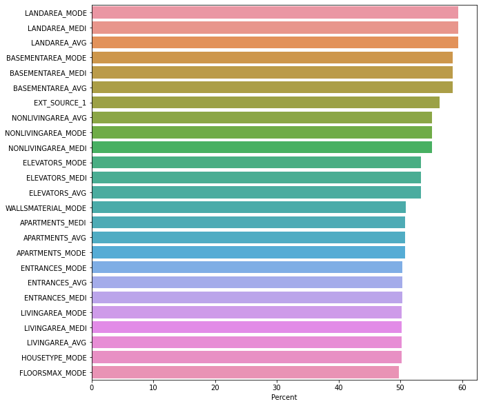

```python
plt.figure(figsize=(10,10))
sns.barplot(y=missing_application_train_data.head(25).index, x=missing_application_train_data.head(25).Percent)
```

## Correlation

### Drop Columns With No Data

```python
# below mentioned columns have only NaNs and 0s
final_appTrainDF = final_appTrainDF.drop(['PREV_POS_SK_DPD_min_min', 'PREV_POS_SK_DPD_DEF_min_min', 'PREV_POS_NAME_CONTRACT_STATUS_XNA_mean_min',
                                         'PREV_POS_NAME_CONTRACT_STATUS_XNA_sum_min', 'PREV_INST_NUM_INSTALMENT_NUMBER_min_min', 'PREV_CC_SK_DPD_min_sum',
                                         'PREV_CC_SK_DPD_DEF_min_sum', 'PREV_CC_DPD_MISSED_min_sum', 'PREV_NAME_GOODS_CATEGORY_House Construction_mean',
                                         'PREV_NAME_GOODS_CATEGORY_House Construction_sum'], axis = 1)
```

```python
# below mentioned columns have only NaNs and 0s
final_appTestDF = final_appTestDF.drop(['PREV_POS_SK_DPD_min_min', 'PREV_POS_SK_DPD_DEF_min_min', 'PREV_POS_NAME_CONTRACT_STATUS_XNA_mean_min',
                                         'PREV_POS_NAME_CONTRACT_STATUS_XNA_sum_min', 'PREV_INST_NUM_INSTALMENT_NUMBER_min_min', 'PREV_CC_SK_DPD_min_sum',
                                         'PREV_CC_SK_DPD_DEF_min_sum', 'PREV_CC_DPD_MISSED_min_sum', 'PREV_NAME_GOODS_CATEGORY_House Construction_mean',
                                         'PREV_NAME_GOODS_CATEGORY_House Construction_sum'], axis = 1);
```

```python
# write out the new application training data
final_appTrainDF.to_csv(DATA_DIR + '/train_clean.csv')
```

```python
# write out the new application test data
final_appTestDF.to_csv(DATA_DIR + '/test_clean.csv')
```

### Top 20 Features Against TARGET - Positive & Negative

```python
correlation_all = final_appTrainDF.corr()['TARGET'].sort_values()

print('Most Positive Correlations with TARGET - Top 20:')
print(correlation_all.tail(20))

print('\nMost Negative Correlations with TARGET - Top 20:')
print(correlation_all.head(20))
```

```
Most Positive Correlations with TARGET - Top 20:
DAYS_LAST_PHONE_CHANGE                       0.055218
PREV_CODE_REJECT_REASON_SCOFR_mean           0.055865
BUR_DAYS_ENDDATE_FACT_min                    0.055887
PREV_CODE_REJECT_REASON_SCOFR_sum            0.056284
PREV_CC_CNT_DRAWINGS_CURRENT_max_sum         0.056757
PREV_NAME_PRODUCT_TYPE_walk-in_mean          0.057412
REGION_RATING_CLIENT                         0.058899
REGION_RATING_CLIENT_W_CITY                  0.060893
PREV_NAME_PRODUCT_TYPE_walk-in_sum           0.062628
PREV_NAME_CONTRACT_STATUS_Refused_sum        0.064469
PREV_CC_CNT_DRAWINGS_ATM_CURRENT_mean_sum    0.065293
BUR_CREDIT_ACTIVE_Active_sum                 0.067128
BUR_DAYS_CREDIT_UPDATE_mean                  0.068927
PREV_INTEREST_PER_CREDIT_max                 0.069125
BUR_DAYS_CREDIT_min                          0.075248
BUR_CREDIT_ACTIVE_Active_mean                0.077356
PREV_NAME_CONTRACT_STATUS_Refused_mean       0.077671
DAYS_BIRTH                                   0.078239
BUR_DAYS_CREDIT_mean                         0.089729
TARGET                                       1.000000
Name: TARGET, dtype: float64

Most Negative Correlations with TARGET - Top 20:
EXT_SOURCE_3                                     -0.178919
EXT_SOURCE_2                                     -0.160472
EXT_SOURCE_1                                     -0.155317
PREV_NAME_CONTRACT_STATUS_Approved_mean          -0.063521
PREV_DAYS_FIRST_DRAWING_mean                     -0.048803
DAYS_EMPLOYED                                    -0.044932
PREV_DAYS_FIRST_DRAWING_min                      -0.044643
FLOORSMAX_AVG                                    -0.044003
FLOORSMAX_MEDI                                   -0.043768
FLOORSMAX_MODE                                   -0.043226
PREV_RATE_DOWN_PAYMENT_sum                       -0.041693
PREV_NAME_YIELD_GROUP_low_normal_mean            -0.041134
PREV_INST_PAY_IS_LATE_mean_sum                   -0.040479
PREV_RATE_DOWN_PAYMENT_max                       -0.040096
AMT_GOODS_PRICE                                  -0.039645
PREV_INTEREST_RT_sum                             -0.039533
PREV_PRODUCT_COMBINATION_Cash X-Sell: low_mean   -0.037494
REGION_POPULATION_RELATIVE                       -0.037227
PREV_INTEREST_RT_mean                            -0.036350
PREV_HOUR_APPR_PROCESS_START_mean                -0.035927
Name: TARGET, dtype: float64
```

### Heat Map - Top Features Against TARGET

```python
correlation_target = final_appTrainDF.corr()['TARGET'].sort_values()

top_correlation_features=[]
for i in correlation_target.head(6).keys().tolist():
    top_correlation_features.append(i)

for i in correlation_target.tail(6).keys().tolist():
    top_correlation_features.append(i)
```

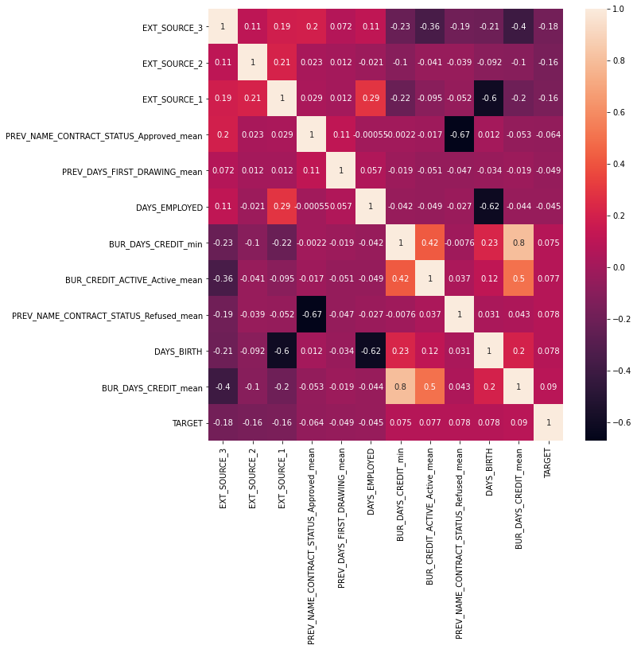

```python
# Correlation Heat Map for Some Top Features
fig, ax = plt.subplots(figsize=(10,10))
sns.heatmap(
    appTrainDF.loc[:, top_correlation_features].corr(),
    annot=True
)
```

# Modeling

## Split Data

```python
# assign the input and response features
X = final_appTrainDF.drop(['SK_ID_CURR', 'TARGET'], axis = 1)
y = final_appTrainDF['TARGET']
```

```python
# split data such that 80% in training and 20% in test
x_train, x_test, y_train, y_test = train_test_split(X, y, stratify=y, test_size=.2, random_state=42)
```

```python
# print the shape of the training data
x_train.shape
```

```
(246008, 647)
```

## Generate a smaller sample for tuning

```python
# split data such that 10% is used for tuning, other 90% used for cross fold validation with best hyperparameters
x_sample_10, x_sample_90, y_sample_10, y_sample_90 = train_test_split(x_train, y_train, stratify=y_train, test_size=.9, random_state=42)
```

```python
x_sample_10.shape
```

```
(24600, 647)
```

## Pipeline

```python
# specify the numeric features
numerical_features = ['CNT_CHILDREN',
                      'AMT_INCOME_TOTAL',
                      'AMT_CREDIT',
                      'AMT_ANNUITY',
                      'AMT_GOODS_PRICE',
                      'REGION_POPULATION_RELATIVE',
                      'DAYS_BIRTH',
                      'DAYS_EMPLOYED',
                      'DAYS_REGISTRATION',
                      'DAYS_ID_PUBLISH',
                      'FLAG_MOBIL',
                      'FLAG_EMP_PHONE',
                      'FLAG_WORK_PHONE',
                      'FLAG_CONT_MOBILE',
                      'FLAG_PHONE',
                      'FLAG_EMAIL',
                      'CNT_FAM_MEMBERS',
                      'REG_REGION_NOT_LIVE_REGION',
                      'REG_REGION_NOT_WORK_REGION',
                      'LIVE_REGION_NOT_WORK_REGION',
                      'REG_CITY_NOT_LIVE_CITY',
                      'REG_CITY_NOT_WORK_CITY',
                      'LIVE_CITY_NOT_WORK_CITY',
                      'EXT_SOURCE_1',
                      'EXT_SOURCE_2',
                      'EXT_SOURCE_3',
                      'APARTMENTS_AVG',
                      'BASEMENTAREA_AVG',
                      'YEARS_BEGINEXPLUATATION_AVG',
                      'ELEVATORS_AVG',
                      'ENTRANCES_AVG',
                      'FLOORSMAX_AVG',
                      'LANDAREA_AVG',
                      'LIVINGAREA_AVG',
                      'NONLIVINGAREA_AVG',
                      'APARTMENTS_MODE',
                      'BASEMENTAREA_MODE',
                      'YEARS_BEGINEXPLUATATION_MODE',
                      'ELEVATORS_MODE',
                      'ENTRANCES_MODE',
                      'FLOORSMAX_MODE',
                      'LANDAREA_MODE',
                      'LIVINGAREA_MODE',
                      'NONLIVINGAREA_MODE',
                      'APARTMENTS_MEDI',
                      'BASEMENTAREA_MEDI',
                      'YEARS_BEGINEXPLUATATION_MEDI',
                      'ELEVATORS_MEDI',
                      'ENTRANCES_MEDI',
                      'FLOORSMAX_MEDI',
                      'LANDAREA_MEDI',
                      'LIVINGAREA_MEDI',
                      'NONLIVINGAREA_MEDI',
                      'TOTALAREA_MODE',
                      'OBS_30_CNT_SOCIAL_CIRCLE',
                      'DEF_30_CNT_SOCIAL_CIRCLE',
                      'OBS_60_CNT_SOCIAL_CIRCLE',
                      'DEF_60_CNT_SOCIAL_CIRCLE',
                      'DAYS_LAST_PHONE_CHANGE',
                      'FLAG_DOCUMENT_2',
                      'FLAG_DOCUMENT_3',
                      'FLAG_DOCUMENT_4',
                      'FLAG_DOCUMENT_5',
                      'FLAG_DOCUMENT_6',
                      'FLAG_DOCUMENT_7',
                      'FLAG_DOCUMENT_8',
                      'FLAG_DOCUMENT_9',
                      'FLAG_DOCUMENT_10',
                      'FLAG_DOCUMENT_11',
                      'FLAG_DOCUMENT_12',
                      'FLAG_DOCUMENT_13',
                      'FLAG_DOCUMENT_14',
                      'FLAG_DOCUMENT_15',
                      'FLAG_DOCUMENT_16',
                      'FLAG_DOCUMENT_17',
                      'FLAG_DOCUMENT_18',
                      'FLAG_DOCUMENT_19',
                      'FLAG_DOCUMENT_20',
                      'FLAG_DOCUMENT_21',
                      'AMT_REQ_CREDIT_BUREAU_HOUR',
                      'AMT_REQ_CREDIT_BUREAU_DAY',
                      'AMT_REQ_CREDIT_BUREAU_WEEK',
                      'AMT_REQ_CREDIT_BUREAU_MON',
                      'AMT_REQ_CREDIT_BUREAU_QRT',
                      'AMT_REQ_CREDIT_BUREAU_YEAR',
                      'PREV_AMT_ANNUITY_min', # Start of fields from merged subsets
                      'PREV_AMT_ANNUITY_max',
                      'PREV_AMT_ANNUITY_mean',
                      'PREV_AMT_ANNUITY_count',
                      'PREV_AMT_ANNUITY_sum',
                      'PREV_AMT_APPLICATION_min',
                      'PREV_AMT_APPLICATION_max',
                      'PREV_AMT_APPLICATION_mean',
                      'PREV_AMT_DOWN_PAYMENT_min',
                      'PREV_AMT_DOWN_PAYMENT_max',
                      'PREV_AMT_DOWN_PAYMENT_count',
                      'PREV_AMT_GOODS_PRICE_min',
                      'PREV_HOUR_APPR_PROCESS_START_min',
                      'PREV_HOUR_APPR_PROCESS_START_max',
                      'PREV_HOUR_APPR_PROCESS_START_mean',
                      'PREV_NFLAG_LAST_APPL_IN_DAY_min',
                      'PREV_NFLAG_LAST_APPL_IN_DAY_max',
                      'PREV_NFLAG_LAST_APPL_IN_DAY_mean',
                      'PREV_RATE_DOWN_PAYMENT_min',
                      'PREV_RATE_DOWN_PAYMENT_max',
                      'PREV_RATE_DOWN_PAYMENT_mean',
                      'PREV_RATE_DOWN_PAYMENT_sum',
                      'PREV_RATE_INTEREST_PRIMARY_count',
                      'PREV_DAYS_DECISION_min',
                      'PREV_DAYS_DECISION_max',
                      'PREV_DAYS_DECISION_mean',
                      'PREV_DAYS_DECISION_sum',
                      'PREV_SELLERPLACE_AREA_min',
                      'PREV_SELLERPLACE_AREA_max',
                      'PREV_SELLERPLACE_AREA_mean',
                      'PREV_SELLERPLACE_AREA_sum',
                      'PREV_CNT_PAYMENT_min',
                      'PREV_CNT_PAYMENT_max',
                      'PREV_CNT_PAYMENT_mean',
                      'PREV_CNT_PAYMENT_sum',
                      'PREV_DAYS_FIRST_DRAWING_min',
                      'PREV_DAYS_FIRST_DRAWING_max',
                      'PREV_DAYS_FIRST_DRAWING_mean',
                      'PREV_DAYS_FIRST_DRAWING_count',
                      'PREV_DAYS_FIRST_DUE_min',
                      'PREV_DAYS_FIRST_DUE_max',
                      'PREV_DAYS_FIRST_DUE_mean',
                      'PREV_DAYS_LAST_DUE_1ST_VERSION_max',
                      'PREV_DAYS_LAST_DUE_1ST_VERSION_mean',
                      'PREV_DAYS_LAST_DUE_min',
                      'PREV_DAYS_LAST_DUE_max',
                      'PREV_DAYS_LAST_DUE_mean',
                      'PREV_DAYS_LAST_DUE_sum',
                      'PREV_NFLAG_INSURED_ON_APPROVAL_min',
                      'PREV_NFLAG_INSURED_ON_APPROVAL_max',
                      'PREV_NFLAG_INSURED_ON_APPROVAL_mean',
                      'PREV_NFLAG_INSURED_ON_APPROVAL_sum',
                      'PREV_POS_MONTHS_BALANCE_min_max',
                      'PREV_POS_MONTHS_BALANCE_min_mean',
                      'PREV_POS_MONTHS_BALANCE_min_sum',
                      'PREV_POS_MONTHS_BALANCE_count_min',
                      'PREV_POS_MONTHS_BALANCE_count_max',
                      'PREV_POS_MONTHS_BALANCE_count_mean',
                      'PREV_POS_MONTHS_BALANCE_count_sum',
                      'PREV_POS_MONTHS_BALANCE_sum_min',
                      'PREV_POS_MONTHS_BALANCE_sum_max',
                      'PREV_POS_MONTHS_BALANCE_sum_mean',
                      'PREV_POS_CNT_INSTALMENT_min_min',
                      'PREV_POS_CNT_INSTALMENT_min_max',
                      'PREV_POS_CNT_INSTALMENT_min_mean',
                      'PREV_POS_CNT_INSTALMENT_max_min',
                      'PREV_POS_CNT_INSTALMENT_max_max',
                      'PREV_POS_CNT_INSTALMENT_max_mean',
                      'PREV_POS_CNT_INSTALMENT_max_sum',
                      'PREV_POS_CNT_INSTALMENT_sum_min',
                      'PREV_POS_CNT_INSTALMENT_sum_max',
                      'PREV_POS_CNT_INSTALMENT_sum_mean',
                      'PREV_POS_CNT_INSTALMENT_sum_sum',
                      'PREV_POS_CNT_INSTALMENT_FUTURE_min_min',
                      'PREV_POS_CNT_INSTALMENT_FUTURE_min_max',
                      'PREV_POS_CNT_INSTALMENT_FUTURE_min_mean',
                      'PREV_POS_SK_DPD_min_max',
                      'PREV_POS_SK_DPD_min_mean',
                      'PREV_POS_SK_DPD_min_sum',
                      'PREV_POS_SK_DPD_max_min',
                      'PREV_POS_SK_DPD_max_max',
                      'PREV_POS_SK_DPD_DEF_min_max',
                      'PREV_POS_SK_DPD_DEF_min_mean',
                      'PREV_POS_SK_DPD_DEF_min_sum',
                      'PREV_POS_NAME_CONTRACT_STATUS_Active_mean_min',
                      'PREV_POS_NAME_CONTRACT_STATUS_Active_mean_max',
                      'PREV_POS_NAME_CONTRACT_STATUS_Active_mean_mean',
                      'PREV_POS_NAME_CONTRACT_STATUS_Approved_mean_min',
                      'PREV_POS_NAME_CONTRACT_STATUS_Approved_mean_max',
                      'PREV_POS_NAME_CONTRACT_STATUS_Canceled_mean_min',
                      'PREV_POS_NAME_CONTRACT_STATUS_Canceled_mean_max',
                      'PREV_POS_NAME_CONTRACT_STATUS_Canceled_mean_mean',
                      'PREV_POS_NAME_CONTRACT_STATUS_Canceled_mean_sum',
                      'PREV_POS_NAME_CONTRACT_STATUS_Canceled_sum_min',
                      'PREV_POS_NAME_CONTRACT_STATUS_Canceled_sum_max',
                      'PREV_POS_NAME_CONTRACT_STATUS_Canceled_sum_mean',
                      'PREV_POS_NAME_CONTRACT_STATUS_Canceled_sum_sum',
                      'PREV_POS_NAME_CONTRACT_STATUS_Completed_sum_min',
                      'PREV_POS_NAME_CONTRACT_STATUS_Completed_sum_max',
                      'PREV_POS_NAME_CONTRACT_STATUS_Completed_sum_sum',
                      'PREV_POS_NAME_CONTRACT_STATUS_Returned to the store_mean_min',
                      'PREV_POS_NAME_CONTRACT_STATUS_Returned to the store_mean_max',
                      'PREV_POS_NAME_CONTRACT_STATUS_Signed_mean_min',
                      'PREV_POS_NAME_CONTRACT_STATUS_Signed_mean_max',
                      'PREV_POS_NAME_CONTRACT_STATUS_Signed_mean_mean',
                      'PREV_POS_NAME_CONTRACT_STATUS_Signed_sum_max',
                      'PREV_POS_NAME_CONTRACT_STATUS_Signed_sum_mean',
                      'PREV_POS_NAME_CONTRACT_STATUS_XNA_mean_max',
                      'PREV_POS_NAME_CONTRACT_STATUS_XNA_mean_mean',
                      'PREV_POS_NAME_CONTRACT_STATUS_XNA_mean_sum',
                      'PREV_POS_NAME_CONTRACT_STATUS_XNA_sum_max',
                      'PREV_POS_NAME_CONTRACT_STATUS_XNA_sum_mean',
                      'PREV_POS_NAME_CONTRACT_STATUS_XNA_sum_sum',
                      'PREV_INST_NUM_INSTALMENT_VERSION_min_max',
                      'PREV_INST_NUM_INSTALMENT_VERSION_min_mean',
                      'PREV_INST_NUM_INSTALMENT_VERSION_max_min',
                      'PREV_INST_NUM_INSTALMENT_VERSION_max_max',
                      'PREV_INST_NUM_INSTALMENT_VERSION_max_mean',
                      'PREV_INST_NUM_INSTALMENT_VERSION_max_sum',
                      'PREV_INST_NUM_INSTALMENT_VERSION_count_min',
                      'PREV_INST_NUM_INSTALMENT_VERSION_count_max',
                      'PREV_INST_NUM_INSTALMENT_VERSION_count_mean',
                      'PREV_INST_NUM_INSTALMENT_VERSION_count_sum',
                      'PREV_INST_NUM_INSTALMENT_VERSION_sum_min',
                      'PREV_INST_NUM_INSTALMENT_VERSION_sum_max',
                      'PREV_INST_NUM_INSTALMENT_VERSION_sum_mean',
                      'PREV_INST_NUM_INSTALMENT_VERSION_sum_sum',
                      'PREV_INST_NUM_INSTALMENT_NUMBER_min_max',
                      'PREV_INST_NUM_INSTALMENT_NUMBER_min_mean',
                      'PREV_INST_DAYS_INSTALMENT_max_max',
                      'PREV_INST_AMT_INSTALMENT_min_min',
                      'PREV_INST_AMT_INSTALMENT_min_max',
                      'PREV_INST_AMT_INSTALMENT_min_mean',
                      'PREV_INST_AMT_INSTALMENT_max_min',
                      'PREV_INST_AMT_INSTALMENT_max_max',
                      'PREV_INST_AMT_INSTALMENT_max_mean',
                      'PREV_INST_AMT_INSTALMENT_mean_min',
                      'PREV_INST_AMT_INSTALMENT_mean_max',
                      'PREV_INST_AMT_INSTALMENT_mean_mean',
                      'PREV_INST_AMT_INSTALMENT_sum_min',
```

```python
                      'PREV_INST_AMT_INSTALMENT_sum_max',
                      'PREV_INST_AMT_INSTALMENT_sum_mean',
                      'PREV_INST_AMT_INSTALMENT_sum_sum',
                      'PREV_INST_PAY_IS_LATE_min_min',
                      'PREV_INST_PAY_IS_LATE_min_max',
                      'PREV_INST_PAY_IS_LATE_max_min',
                      'PREV_INST_PAY_IS_LATE_max_max',
                      'PREV_INST_PAY_IS_LATE_max_mean',
                      'PREV_INST_PAY_IS_LATE_max_sum',
                      'PREV_INST_PAY_IS_LATE_mean_min',
                      'PREV_INST_PAY_IS_LATE_mean_max',
                      'PREV_INST_PAY_IS_LATE_mean_mean',
                      'PREV_INST_PAY_IS_LATE_mean_sum',
                      'PREV_INST_PAY_IS_LATE_sum_min',
                      'PREV_INST_PAY_IS_LATE_sum_max',
                      'PREV_INST_PAY_IS_LATE_sum_mean',
                      'PREV_INST_PAY_IS_LATE_sum_sum',
                      'PREV_INST_AMT_MISSED_min_min',
                      'PREV_INST_AMT_MISSED_min_max',
                      'PREV_INST_AMT_MISSED_min_mean',
                      'PREV_INST_AMT_MISSED_max_min',
                      'PREV_INST_AMT_MISSED_max_max',
                      'PREV_INST_AMT_MISSED_max_mean',
                      'PREV_INST_AMT_MISSED_mean_min',
                      'PREV_INST_AMT_MISSED_mean_max',
                      'PREV_INST_AMT_MISSED_sum_max',
                      'PREV_INST_AMT_MISSED_sum_mean',
                      'PREV_INST_AMT_MISSED_sum_sum',
                      'PREV_CC_MONTHS_BALANCE_min_sum',
                      'PREV_CC_MONTHS_BALANCE_max_sum',
                      'PREV_CC_AMT_BALANCE_min_sum',
                      'PREV_CC_AMT_BALANCE_max_sum',
                      'PREV_CC_AMT_BALANCE_mean_sum',
                      'PREV_CC_AMT_BALANCE_sum_sum',
                      'PREV_CC_AMT_CREDIT_LIMIT_ACTUAL_min_sum',
                      'PREV_CC_AMT_CREDIT_LIMIT_ACTUAL_max_sum',
                      'PREV_CC_AMT_CREDIT_LIMIT_ACTUAL_sum_sum',
                      'PREV_CC_AMT_DRAWINGS_ATM_CURRENT_min_sum',
                      'PREV_CC_AMT_DRAWINGS_ATM_CURRENT_max_sum',
                      'PREV_CC_AMT_DRAWINGS_ATM_CURRENT_mean_sum',
                      'PREV_CC_AMT_DRAWINGS_ATM_CURRENT_sum_sum',
                      'PREV_CC_AMT_DRAWINGS_CURRENT_max_sum',
                      'PREV_CC_AMT_DRAWINGS_CURRENT_mean_sum',
                      'PREV_CC_AMT_DRAWINGS_OTHER_CURRENT_min_sum',
                      'PREV_CC_AMT_DRAWINGS_OTHER_CURRENT_max_sum',
                      'PREV_CC_AMT_DRAWINGS_POS_CURRENT_max_sum',
                      'PREV_CC_AMT_INST_MIN_REGULARITY_min_sum',
                      'PREV_CC_AMT_PAYMENT_CURRENT_max_sum',
                      'PREV_CC_CNT_DRAWINGS_ATM_CURRENT_max_sum',
                      'PREV_CC_CNT_DRAWINGS_ATM_CURRENT_mean_sum',
                      'PREV_CC_CNT_DRAWINGS_ATM_CURRENT_sum_sum',
                      'PREV_CC_CNT_DRAWINGS_CURRENT_max_sum',
                      'PREV_CC_CNT_DRAWINGS_CURRENT_mean_sum',
                      'PREV_CC_CNT_DRAWINGS_OTHER_CURRENT_min_sum',
                      'PREV_CC_CNT_DRAWINGS_OTHER_CURRENT_sum_sum',
                      'PREV_CC_CNT_INSTALMENT_MATURE_CUM_min_sum',
                      'PREV_CC_CNT_INSTALMENT_MATURE_CUM_max_sum',
                      'PREV_CC_SK_DPD_max_sum',
                      'PREV_CC_SK_DPD_DEF_max_sum',
                      'PREV_CC_SK_DPD_DEF_mean_sum',
                      'PREV_CC_CREDIT_UTILIZED_min_sum',
                      'PREV_CC_NAME_CONTRACT_STATUS_Approved_mean_sum',
                      'PREV_CC_NAME_CONTRACT_STATUS_Approved_sum_sum',
                      'PREV_CC_NAME_CONTRACT_STATUS_Completed_sum_sum',
                      'PREV_CC_NAME_CONTRACT_STATUS_Demand_mean_sum',
                      'PREV_CC_NAME_CONTRACT_STATUS_Demand_sum_sum',
                      'PREV_CC_NAME_CONTRACT_STATUS_Refused_mean_sum',
                      'PREV_CC_NAME_CONTRACT_STATUS_Refused_sum_sum',
                      'PREV_CC_NAME_CONTRACT_STATUS_Sent proposal_mean_sum',
                      'PREV_CC_NAME_CONTRACT_STATUS_Signed_mean_sum',
                      'PREV_CC_NAME_CONTRACT_STATUS_Signed_sum_sum',
                      'PREV_INTEREST_min',
                      'PREV_INTEREST_max',
                      'PREV_INTEREST_mean',
                      'PREV_INTEREST_sum',
                      'PREV_INTEREST_PER_CREDIT_min',
                      'PREV_INTEREST_PER_CREDIT_max',
                      'PREV_INTEREST_PER_CREDIT_mean',
                      'PREV_INTEREST_PER_CREDIT_sum',
                      'PREV_CREDIT_SUCCESS_min',
                      'PREV_CREDIT_SUCCESS_max',
                      'PREV_CREDIT_SUCCESS_mean',
                      'PREV_CREDIT_SUCCESS_sum',
                      'PREV_INTEREST_RT_max',
                      'PREV_INTEREST_RT_mean',
                      'PREV_INTEREST_RT_sum',
                      'PREV_NAME_CONTRACT_TYPE_Cash loans_mean',
                      'PREV_NAME_CONTRACT_TYPE_Cash loans_sum',
                      'PREV_NAME_CONTRACT_TYPE_Consumer loans_mean',
                      'PREV_NAME_CONTRACT_TYPE_Revolving loans_sum',
                      'PREV_NAME_CONTRACT_TYPE_XNA_mean',
                      'PREV_WEEKDAY_APPR_PROCESS_START_FRIDAY_mean',
                      'PREV_WEEKDAY_APPR_PROCESS_START_FRIDAY_sum',
                      'PREV_WEEKDAY_APPR_PROCESS_START_MONDAY_mean',
                      'PREV_WEEKDAY_APPR_PROCESS_START_MONDAY_sum',
                      'PREV_WEEKDAY_APPR_PROCESS_START_SATURDAY_mean',
                      'PREV_WEEKDAY_APPR_PROCESS_START_SATURDAY_sum',
                      'PREV_WEEKDAY_APPR_PROCESS_START_SUNDAY_mean',
                      'PREV_WEEKDAY_APPR_PROCESS_START_SUNDAY_sum',
                      'PREV_WEEKDAY_APPR_PROCESS_START_THURSDAY_mean',
                      'PREV_WEEKDAY_APPR_PROCESS_START_THURSDAY_sum',
                      'PREV_WEEKDAY_APPR_PROCESS_START_TUESDAY_mean',
                      'PREV_WEEKDAY_APPR_PROCESS_START_TUESDAY_sum',
                      'PREV_WEEKDAY_APPR_PROCESS_START_WEDNESDAY_mean',
                      'PREV_WEEKDAY_APPR_PROCESS_START_WEDNESDAY_sum',
                      'PREV_NAME_CASH_LOAN_PURPOSE_Building a house or an annex_mean',
                      'PREV_NAME_CASH_LOAN_PURPOSE_Business development_mean',
                      'PREV_NAME_CASH_LOAN_PURPOSE_Business development_sum',
                      'PREV_NAME_CASH_LOAN_PURPOSE_Buying a garage_mean',
                      'PREV_NAME_CASH_LOAN_PURPOSE_Buying a garage_sum',
                      'PREV_NAME_CASH_LOAN_PURPOSE_Buying a holiday home / land_mean',
                      'PREV_NAME_CASH_LOAN_PURPOSE_Buying a home_mean',
                      'PREV_NAME_CASH_LOAN_PURPOSE_Buying a new car_mean',
                      'PREV_NAME_CASH_LOAN_PURPOSE_Buying a new car_sum',
                      'PREV_NAME_CASH_LOAN_PURPOSE_Buying a used car_mean',
                      'PREV_NAME_CASH_LOAN_PURPOSE_Car repairs_mean',
                      'PREV_NAME_CASH_LOAN_PURPOSE_Car repairs_sum',
                      'PREV_NAME_CASH_LOAN_PURPOSE_Education_mean',
                      'PREV_NAME_CASH_LOAN_PURPOSE_Everyday expenses_mean',
                      'PREV_NAME_CASH_LOAN_PURPOSE_Everyday expenses_sum',
                      'PREV_NAME_CASH_LOAN_PURPOSE_Furniture_mean',
                      'PREV_NAME_CASH_LOAN_PURPOSE_Gasification / water supply_mean',
                      'PREV_NAME_CASH_LOAN_PURPOSE_Gasification / water supply_sum',
                      'PREV_NAME_CASH_LOAN_PURPOSE_Hobby_mean',
                      'PREV_NAME_CASH_LOAN_PURPOSE_Hobby_sum',
                      'PREV_NAME_CASH_LOAN_PURPOSE_Journey_mean',
                      'PREV_NAME_CASH_LOAN_PURPOSE_Medicine_mean',
                      'PREV_NAME_CASH_LOAN_PURPOSE_Medicine_sum',
                      'PREV_NAME_CASH_LOAN_PURPOSE_Money for a third person_mean',
                      'PREV_NAME_CASH_LOAN_PURPOSE_Money for a third person_sum',
                      'PREV_NAME_CASH_LOAN_PURPOSE_Other_mean',
                      'PREV_NAME_CASH_LOAN_PURPOSE_Other_sum',
                      'PREV_NAME_CASH_LOAN_PURPOSE_Payments on other loans_mean',
                      'PREV_NAME_CASH_LOAN_PURPOSE_Purchase of electronic equipment_mean',
                      'PREV_NAME_CASH_LOAN_PURPOSE_Refusal to name the goal_mean',
                      'PREV_NAME_CASH_LOAN_PURPOSE_Refusal to name the goal_sum',
                      'PREV_NAME_CASH_LOAN_PURPOSE_Repairs_mean',
                      'PREV_NAME_CASH_LOAN_PURPOSE_Repairs_sum',
                      'PREV_NAME_CASH_LOAN_PURPOSE_Urgent needs_mean',
                      'PREV_NAME_CASH_LOAN_PURPOSE_Urgent needs_sum',
                      'PREV_NAME_CASH_LOAN_PURPOSE_Wedding / gift / holiday_mean',
                      'PREV_NAME_CASH_LOAN_PURPOSE_Wedding / gift / holiday_sum',
                      'PREV_NAME_CASH_LOAN_PURPOSE_XAP_sum',
                      'PREV_NAME_CONTRACT_STATUS_Approved_mean',
                      'PREV_NAME_CONTRACT_STATUS_Canceled_mean',
                      'PREV_NAME_CONTRACT_STATUS_Canceled_sum',
                      'PREV_NAME_CONTRACT_STATUS_Refused_mean',
                      'PREV_NAME_CONTRACT_STATUS_Refused_sum',
                      'PREV_NAME_CONTRACT_STATUS_Unused offer_mean',
                      'PREV_NAME_CONTRACT_STATUS_Unused offer_sum',
                      'PREV_NAME_PAYMENT_TYPE_Cash through the bank_mean',
                      'PREV_NAME_PAYMENT_TYPE_Cashless from the account of the employer_mean',
                      'PREV_NAME_PAYMENT_TYPE_Non-cash from your account_mean',
                      'PREV_NAME_PAYMENT_TYPE_Non-cash from your account_sum',
                      'PREV_NAME_PAYMENT_TYPE_XNA_sum',
                      'PREV_CODE_REJECT_REASON_HC_mean',
                      'PREV_CODE_REJECT_REASON_HC_sum',
                      'PREV_CODE_REJECT_REASON_LIMIT_mean',
                      'PREV_CODE_REJECT_REASON_LIMIT_sum',
                      'PREV_CODE_REJECT_REASON_SCO_mean',
                      'PREV_CODE_REJECT_REASON_SCO_sum',
                      'PREV_CODE_REJECT_REASON_SCOFR_mean',
                      'PREV_CODE_REJECT_REASON_SCOFR_sum',
                      'PREV_CODE_REJECT_REASON_SYSTEM_mean',
                      'PREV_CODE_REJECT_REASON_VERIF_mean',
                      'PREV_CODE_REJECT_REASON_VERIF_sum',
                      'PREV_CODE_REJECT_REASON_XNA_mean',
                      'PREV_CODE_REJECT_REASON_XNA_sum',
                      'PREV_NAME_TYPE_SUITE_Children_mean',
                      'PREV_NAME_TYPE_SUITE_Children_sum',
                      'PREV_NAME_TYPE_SUITE_Family_mean',
                      'PREV_NAME_TYPE_SUITE_Family_sum',
                      'PREV_NAME_TYPE_SUITE_Group of people_mean',
                      'PREV_NAME_TYPE_SUITE_Other_A_mean',
                      'PREV_NAME_TYPE_SUITE_Other_A_sum',
                      'PREV_NAME_TYPE_SUITE_Other_B_mean',
                      'PREV_NAME_TYPE_SUITE_Other_B_sum',
                      'PREV_NAME_TYPE_SUITE_Spouse, partner_mean',
                      'PREV_NAME_TYPE_SUITE_Spouse, partner_sum',
                      'PREV_NAME_TYPE_SUITE_Unaccompanied_mean',
                      'PREV_NAME_TYPE_SUITE_Unaccompanied_sum',
                      'PREV_NAME_CLIENT_TYPE_New_mean',
                      'PREV_NAME_CLIENT_TYPE_New_sum',
                      'PREV_NAME_CLIENT_TYPE_Refreshed_mean',
                      'PREV_NAME_CLIENT_TYPE_Refreshed_sum',
                      'PREV_NAME_CLIENT_TYPE_Repeater_mean',
                      'PREV_NAME_CLIENT_TYPE_XNA_mean',
                      'PREV_NAME_GOODS_CATEGORY_Additional Service_mean',
                      'PREV_NAME_GOODS_CATEGORY_Additional Service_sum',
```

```python
                      'PREV_NAME_GOODS_CATEGORY_Animals_mean',
                      'PREV_NAME_GOODS_CATEGORY_Animals_sum',
                      'PREV_NAME_GOODS_CATEGORY_Audio/Video_mean',
                      'PREV_NAME_GOODS_CATEGORY_Audio/Video_sum',
                      'PREV_NAME_GOODS_CATEGORY_Auto Accessories_mean',
                      'PREV_NAME_GOODS_CATEGORY_Auto Accessories_sum',
                      'PREV_NAME_GOODS_CATEGORY_Clothing and Accessories_mean',
                      'PREV_NAME_GOODS_CATEGORY_Clothing and Accessories_sum',
                      'PREV_NAME_GOODS_CATEGORY_Computers_mean',
                      'PREV_NAME_GOODS_CATEGORY_Computers_sum',
                      'PREV_NAME_GOODS_CATEGORY_Construction Materials_mean',
                      'PREV_NAME_GOODS_CATEGORY_Construction Materials_sum',
                      'PREV_NAME_GOODS_CATEGORY_Consumer Electronics_mean',
                      'PREV_NAME_GOODS_CATEGORY_Consumer Electronics_sum',
                      'PREV_NAME_GOODS_CATEGORY_Direct Sales_mean',
                      'PREV_NAME_GOODS_CATEGORY_Education_mean',
                      'PREV_NAME_GOODS_CATEGORY_Education_sum',
                      'PREV_NAME_GOODS_CATEGORY_Fitness_mean',
                      'PREV_NAME_GOODS_CATEGORY_Fitness_sum',
                      'PREV_NAME_GOODS_CATEGORY_Furniture_mean',
                      'PREV_NAME_GOODS_CATEGORY_Furniture_sum',
                      'PREV_NAME_GOODS_CATEGORY_Gardening_mean',
                      'PREV_NAME_GOODS_CATEGORY_Gardening_sum',
                      'PREV_NAME_GOODS_CATEGORY_Homewares_mean',
                      'PREV_NAME_GOODS_CATEGORY_Homewares_sum',
                      'PREV_NAME_GOODS_CATEGORY_Insurance_mean',
                      'PREV_NAME_GOODS_CATEGORY_Insurance_sum',
                      'PREV_NAME_GOODS_CATEGORY_Jewelry_mean',
                      'PREV_NAME_GOODS_CATEGORY_Jewelry_sum',
                      'PREV_NAME_GOODS_CATEGORY_Medical Supplies_mean',
                      'PREV_NAME_GOODS_CATEGORY_Medicine_mean',
                      'PREV_NAME_GOODS_CATEGORY_Medicine_sum',
                      'PREV_NAME_GOODS_CATEGORY_Mobile_mean',
                      'PREV_NAME_GOODS_CATEGORY_Mobile_sum',
                      'PREV_NAME_GOODS_CATEGORY_Office Appliances_mean',
                      'PREV_NAME_GOODS_CATEGORY_Office Appliances_sum',
                      'PREV_NAME_GOODS_CATEGORY_Other_mean',
                      'PREV_NAME_GOODS_CATEGORY_Other_sum',
                      'PREV_NAME_GOODS_CATEGORY_Photo / Cinema Equipment_mean',
                      'PREV_NAME_GOODS_CATEGORY_Photo / Cinema Equipment_sum',
                      'PREV_NAME_GOODS_CATEGORY_Sport and Leisure_mean',
                      'PREV_NAME_GOODS_CATEGORY_Sport and Leisure_sum',
                      'PREV_NAME_GOODS_CATEGORY_Tourism_mean',
                      'PREV_NAME_GOODS_CATEGORY_Tourism_sum',
                      'PREV_NAME_GOODS_CATEGORY_Vehicles_mean',
                      'PREV_NAME_GOODS_CATEGORY_Vehicles_sum',
                      'PREV_NAME_GOODS_CATEGORY_Weapon_mean',
                      'PREV_NAME_PORTFOLIO_Cars_mean',
                      'PREV_NAME_PORTFOLIO_Cash_mean',
                      'PREV_NAME_PORTFOLIO_Cash_sum',
                      'PREV_NAME_PORTFOLIO_XNA_mean',
                      'PREV_NAME_PRODUCT_TYPE_XNA_mean',
                      'PREV_NAME_PRODUCT_TYPE_XNA_sum',
                      'PREV_NAME_PRODUCT_TYPE_walk-in_mean',
                      'PREV_NAME_PRODUCT_TYPE_walk-in_sum',
                      'PREV_NAME_PRODUCT_TYPE_x-sell_mean',
                      'PREV_NAME_PRODUCT_TYPE_x-sell_sum',
                      'PREV_CHANNEL_TYPE_AP+ (Cash loan)_mean',
                      'PREV_CHANNEL_TYPE_AP+ (Cash loan)_sum',
                      'PREV_CHANNEL_TYPE_Channel of corporate sales_mean',
                      'PREV_CHANNEL_TYPE_Channel of corporate sales_sum',
                      'PREV_CHANNEL_TYPE_Contact center_mean',
                      'PREV_CHANNEL_TYPE_Contact center_sum',
                      'PREV_CHANNEL_TYPE_Country-wide_mean',
                      'PREV_CHANNEL_TYPE_Country-wide_sum',
                      'PREV_CHANNEL_TYPE_Credit and cash offices_mean',
                      'PREV_CHANNEL_TYPE_Regional / Local_mean',
                      'PREV_CHANNEL_TYPE_Regional / Local_sum',
                      'PREV_CHANNEL_TYPE_Stone_mean',
                      'PREV_CHANNEL_TYPE_Stone_sum',
                      'PREV_NAME_SELLER_INDUSTRY_Auto technology_mean',
                      'PREV_NAME_SELLER_INDUSTRY_Auto technology_sum',
                      'PREV_NAME_SELLER_INDUSTRY_Connectivity_mean',
                      'PREV_NAME_SELLER_INDUSTRY_Connectivity_sum',
                      'PREV_NAME_SELLER_INDUSTRY_Construction_mean',
                      'PREV_NAME_SELLER_INDUSTRY_Construction_sum',
                      'PREV_NAME_SELLER_INDUSTRY_Consumer electronics_mean',
                      'PREV_NAME_SELLER_INDUSTRY_Consumer electronics_sum',
                      'PREV_NAME_SELLER_INDUSTRY_Furniture_sum',
                      'PREV_NAME_SELLER_INDUSTRY_Industry_mean',
                      'PREV_NAME_SELLER_INDUSTRY_Industry_sum',
                      'PREV_NAME_SELLER_INDUSTRY_Jewelry_mean',
                      'PREV_NAME_SELLER_INDUSTRY_Jewelry_sum',
                      'PREV_NAME_SELLER_INDUSTRY_MLM partners_mean',
                      'PREV_NAME_SELLER_INDUSTRY_MLM partners_sum',
                      'PREV_NAME_SELLER_INDUSTRY_Tourism_mean',
                      'PREV_NAME_YIELD_GROUP_XNA_mean',
                      'PREV_NAME_YIELD_GROUP_high_mean',
                      'PREV_NAME_YIELD_GROUP_high_sum',
                      'PREV_NAME_YIELD_GROUP_low_action_mean',
                      'PREV_NAME_YIELD_GROUP_low_action_sum',
                      'PREV_NAME_YIELD_GROUP_low_normal_mean',
                      'PREV_NAME_YIELD_GROUP_low_normal_sum',
                      'PREV_NAME_YIELD_GROUP_middle_mean',
                      'PREV_NAME_YIELD_GROUP_middle_sum',
                      'PREV_PRODUCT_COMBINATION_Card Street_mean',
                      'PREV_PRODUCT_COMBINATION_Card Street_sum',
                      'PREV_PRODUCT_COMBINATION_Card X-Sell_mean',
                      'PREV_PRODUCT_COMBINATION_Card X-Sell_sum',
                      'PREV_PRODUCT_COMBINATION_Cash_mean',
                      'PREV_PRODUCT_COMBINATION_Cash Street: high_mean',
                      'PREV_PRODUCT_COMBINATION_Cash Street: high_sum',
                      'PREV_PRODUCT_COMBINATION_Cash Street: low_mean',
                      'PREV_PRODUCT_COMBINATION_Cash Street: low_sum',
                      'PREV_PRODUCT_COMBINATION_Cash Street: middle_mean',
                      'PREV_PRODUCT_COMBINATION_Cash Street: middle_sum',
                      'PREV_PRODUCT_COMBINATION_Cash X-Sell: high_mean',
                      'PREV_PRODUCT_COMBINATION_Cash X-Sell: high_sum',
                      'PREV_PRODUCT_COMBINATION_Cash X-Sell: low_mean',
                      'PREV_PRODUCT_COMBINATION_Cash X-Sell: low_sum',
                      'PREV_PRODUCT_COMBINATION_Cash X-Sell: middle_mean',
                      'PREV_PRODUCT_COMBINATION_Cash X-Sell: middle_sum',
                      'PREV_PRODUCT_COMBINATION_POS household with interest_mean',
                      'PREV_PRODUCT_COMBINATION_POS household with interest_sum',
                      'PREV_PRODUCT_COMBINATION_POS household without interest_mean',
                      'PREV_PRODUCT_COMBINATION_POS household without interest_sum',
                      'PREV_PRODUCT_COMBINATION_POS industry with interest_mean',
                      'PREV_PRODUCT_COMBINATION_POS industry with interest_sum',
                      'PREV_PRODUCT_COMBINATION_POS industry without interest_mean',
                      'PREV_PRODUCT_COMBINATION_POS industry without interest_sum',
                      'PREV_PRODUCT_COMBINATION_POS mobile without interest_mean',
                      'PREV_PRODUCT_COMBINATION_POS mobile without interest_sum',
                      'PREV_PRODUCT_COMBINATION_POS other with interest_mean',
                      'PREV_PRODUCT_COMBINATION_POS other with interest_sum',
                      'PREV_PRODUCT_COMBINATION_POS others without interest_mean',
                      'PREV_PRODUCT_COMBINATION_POS others without interest_sum',
                      'BUR_DAYS_CREDIT_min',
                      'BUR_DAYS_CREDIT_max',
                      'BUR_DAYS_CREDIT_mean',
                      'BUR_DAYS_CREDIT_count',
                      'BUR_DAYS_CREDIT_sum',
                      'BUR_CREDIT_DAY_OVERDUE_min',
                      'BUR_CREDIT_DAY_OVERDUE_max',
                      'BUR_DAYS_CREDIT_ENDDATE_min',
                      'BUR_DAYS_CREDIT_ENDDATE_max',
                      'BUR_DAYS_CREDIT_ENDDATE_mean',
                      'BUR_DAYS_CREDIT_ENDDATE_sum',
                      'BUR_DAYS_ENDDATE_FACT_min',
                      'BUR_DAYS_ENDDATE_FACT_max',
                      'BUR_DAYS_ENDDATE_FACT_mean',
                      'BUR_AMT_CREDIT_MAX_OVERDUE_min',
                      'BUR_AMT_CREDIT_MAX_OVERDUE_max',
                      'BUR_AMT_CREDIT_MAX_OVERDUE_count',
                      'BUR_CNT_CREDIT_PROLONG_min',
                      'BUR_CNT_CREDIT_PROLONG_max',
                      'BUR_CNT_CREDIT_PROLONG_mean',
                      'BUR_AMT_CREDIT_SUM_min',
                      'BUR_AMT_CREDIT_SUM_max',
                      'BUR_AMT_CREDIT_SUM_mean',
                      'BUR_AMT_CREDIT_SUM_sum',
                      'BUR_AMT_CREDIT_SUM_DEBT_min',
                      'BUR_AMT_CREDIT_SUM_DEBT_max',
                      'BUR_AMT_CREDIT_SUM_DEBT_mean',
                      'BUR_AMT_CREDIT_SUM_LIMIT_min',
                      'BUR_AMT_CREDIT_SUM_LIMIT_max',
                      'BUR_AMT_CREDIT_SUM_LIMIT_mean',
                      'BUR_AMT_CREDIT_SUM_OVERDUE_min',
                      'BUR_AMT_CREDIT_SUM_OVERDUE_max',
                      'BUR_DAYS_CREDIT_UPDATE_min',
                      'BUR_DAYS_CREDIT_UPDATE_max',
                      'BUR_DAYS_CREDIT_UPDATE_mean',
                      'BUR_AMT_ANNUITY_count',
                      'BUR_AMT_ANNUITY_sum',
                      'BUR_BURBAL_MONTHS_BALANCE_max_sum',
                      'BUR_BURBAL_STATUS_0_mean_sum',
                      'BUR_BURBAL_STATUS_0_sum_sum',
                      'BUR_BURBAL_STATUS_1_mean_sum',
                      'BUR_BURBAL_STATUS_1_sum_sum',
                      'BUR_BURBAL_STATUS_C_mean_sum',
                      'BUR_BURBAL_STATUS_X_mean_sum',
                      'BUR_BURBAL_STATUS_X_sum_sum',
                      'BUR_CREDIT_ACTIVE_Active_mean',
                      'BUR_CREDIT_ACTIVE_Active_sum',
                      'BUR_CREDIT_ACTIVE_Bad debt_mean',
                      'BUR_CREDIT_ACTIVE_Bad debt_sum',
                      'BUR_CREDIT_ACTIVE_Sold_mean',
                      'BUR_CREDIT_ACTIVE_Sold_sum',
                      'BUR_CREDIT_CURRENCY_currency 1_mean',
                      'BUR_CREDIT_CURRENCY_currency 3_mean',
                      'BUR_CREDIT_CURRENCY_currency 3_sum',
                      'BUR_CREDIT_CURRENCY_currency 4_mean',
                      'BUR_CREDIT_CURRENCY_currency 4_sum',
                      'BUR_CREDIT_TYPE_Another type of loan_mean',
                      'BUR_CREDIT_TYPE_Car loan_mean',
                      'BUR_CREDIT_TYPE_Car loan_sum',
                      'BUR_CREDIT_TYPE_Cash loan (non-earmarked)_mean',
                      'BUR_CREDIT_TYPE_Cash loan (non-earmarked)_sum',
                      'BUR_CREDIT_TYPE_Consumer credit_mean',
                      'BUR_CREDIT_TYPE_Credit card_mean',
                      'BUR_CREDIT_TYPE_Credit card_sum',
```

```python
                      'BUR_CREDIT_TYPE_Interbank credit_mean',
                      'BUR_CREDIT_TYPE_Interbank credit_sum',
                      'BUR_CREDIT_TYPE_Loan for business development_mean',
                      'BUR_CREDIT_TYPE_Loan for business development_sum',
                      'BUR_CREDIT_TYPE_Loan for purchase of shares (margin lending)_mean',
                      'BUR_CREDIT_TYPE_Loan for purchase of shares (margin lending)_sum',
                      'BUR_CREDIT_TYPE_Loan for the purchase of equipment_mean',
                      'BUR_CREDIT_TYPE_Loan for the purchase of equipment_sum',
                      'BUR_CREDIT_TYPE_Loan for working capital replenishment_mean',
                      'BUR_CREDIT_TYPE_Microloan_mean',
                      'BUR_CREDIT_TYPE_Microloan_sum',
                      'BUR_CREDIT_TYPE_Mobile operator loan_mean',
                      'BUR_CREDIT_TYPE_Mobile operator loan_sum',
                      'BUR_CREDIT_TYPE_Mortgage_mean',
                      'BUR_CREDIT_TYPE_Mortgage_sum',
                      'BUR_CREDIT_TYPE_Real estate loan_mean',
                      'BUR_CREDIT_TYPE_Real estate loan_sum',
                      'BUR_CREDIT_TYPE_Unknown type of loan_mean',
                      'CREDIT_INCOME_RATIO',
                      'ANNUITY_INCOME_RATIO',
                      'CREDIT_LENGTH',
                      'INCOME_AGE_RATIO',
                      'CREDIT_AGE_RATIO',
                      'DAYS_EMPLOYED_PERCENT']

# specify the categorical features
categorical_features = ['NAME_CONTRACT_TYPE', # start of loan features
                        'NAME_TYPE_SUITE',
                        'NAME_INCOME_TYPE', # start of client demographic features
                        'NAME_EDUCATION_TYPE',
                        'CODE_GENDER',
                        'NAME_FAMILY_STATUS', # start of family features
                        'NAME_HOUSING_TYPE', # start of housing features
                        'HOUSETYPE_MODE',
                        'WALLSMATERIAL_MODE',
                        'EMERGENCYSTATE_MODE',
                        'FLAG_OWN_CAR',
                        'FLAG_OWN_REALTY',
                        'OCCUPATION_TYPE', # start of occupation features
                        'ORGANIZATION_TYPE',
                        'HOUR_APPR_PROCESS_START', # start of application process time features
                        'WEEKDAY_APPR_PROCESS_START',
                        'REGION_RATING_CLIENT', # start of region features
                        'REGION_RATING_CLIENT_W_CITY',
                        'HAS_LIBAILITY'] # new field from application dataset
```

### Set the data pipeline

```python
# create pipeline for numeric features
num_pipeline = Pipeline([
        ('imputer', SimpleImputer(strategy="median")),
        ('std_scaler', StandardScaler()),
    ])

# create pipeline for categorical features
cat_pipeline = Pipeline([
        ('imputer', SimpleImputer(strategy='constant', fill_value="Unknown")),
        ('ohe', OneHotEncoder(sparse=False, handle_unknown="ignore"))
    ])

# specify the column transformer for numeric and categorical features
data_pipeline = ColumnTransformer(
    [("num_pipeline", num_pipeline, numerical_features),
    ("cat_pipeline", cat_pipeline, categorical_features)],
    remainder='passthrough')
```

```python
# test the transformer
X_train_transformed = data_pipeline.fit_transform(x_train)

column_names = numerical_features  + \
               list(data_pipeline.transformers_[1][1].named_steps["ohe"].get_feature_names(categorical_features))

display(pd.DataFrame(X_train_transformed,  columns=column_names).head())
```

|  | CNT_CHILDREN | AMT_INCOME_TOTAL | AMT_CREDIT | AMT_ANNUITY | AMT_GOODS_PRICE | REGION_POPULATION_RELATIVE | DAYS_BIRTH | DAYS_EMPLOYED | DAYS_REGISTRATION | DAYS_ID_PUBLISH | FLAG_MOBIL | FLAG_EMP_PHONE | FLAG_WORK_PHONE | FLAG_CONT_MOBILE | FLAG_PHONE | FLAG_EMAIL | CNT_FAM_MEMBERS | REG_REGION_NOT_LIVE_REGION | REG_REGION_NOT_WORK_REGION | LIVE_REGION_NOT_WORK_REGION | REG_CITY_NOT_LIVE_CITY | REG_CITY_NOT_WORK_CITY | LIVE_CITY_NOT_WORK_CITY | EXT_SOURCE_1 | EXT_SOURCE_2 | EXT_SOURCE_3 | APARTMENTS_AVG | BASEMENTAREA_AVG | YEARS_BEGINEXPLUATATION_AVG | … |
| --- | --- | --- | --- | --- | --- | --- | --- | --- | --- | --- | --- | --- | --- | --- | --- | --- | --- | --- | --- | --- | --- | --- | --- | --- | --- | --- | --- | --- | --- | --- |
| 0 | 2.200964 | -0.304499 | -0.923256 | -0.958536 | -0.970592 | -0.912809 | 0.855291 | -0.457375 | -0.393927 | -1.111106 | 0.002016 | 0.467699 | -0.499501 | 0.043377 | -0.625067 | -0.245247 | 2.034621 | -0.123486 | -0.232186 | -0.207223 | -0.290648 | -0.548149 | -0.469093 | -0.853253 | -1.177591 | 0.613836 | 1.555386 | 1.491306 | 0.128367 | … |
| 1 | -0.578749 | -0.304499 | -1.086618 | -0.965044 | -1.092399 | -1.285861 | 0.150020 | -0.451322 | 1.049094 | 0.663110 | 0.002016 | 0.467699 | -0.499501 | 0.043377 | -0.625067 | -0.245247 | -0.167378 | -0.123486 | -0.232186 | -0.207223 | -0.290648 | 1.824323 | 2.131776 | 0.011861 | -0.000805 | 0.112012 | -0.190035 | -0.093977 | 0.047148 | … |
| 2 | -0.578749 | -0.130727 | 0.321581 | -0.055163 | 0.040404 | -0.010501 | -0.751224 | -0.462337 | -0.840225 | 0.100877 | 0.002016 | 0.467699 | -0.499501 | 0.043377 | 1.599829 | -0.245247 | -1.268377 | -0.123486 | -0.232186 | -0.207223 | -0.290648 | -0.548149 | -0.469093 | 0.011861 | -0.144074 | 0.476446 | 0.596761 | 0.578228 | 0.221189 | … |
| 3 | -0.578749 | -0.130727 | -0.310771 | 0.518471 | -0.398100 | -0.661770 | -0.403745 | -0.462372 | 1.122579 | 1.093404 | 0.002016 | 0.467699 | -0.499501 | 0.043377 | 1.599829 | -0.245247 | -1.268377 | -0.123486 | -0.232186 | -0.207223 | -0.290648 | -0.548149 | -0.469093 | 0.011861 | 0.844742 | -0.351504 | -1.215841 | -1.029461 | -0.263806 | … |
| 4 | -0.578749 | 0.043045 | -0.855766 | 0.030990 | -0.848785 | -1.028534 | 1.729030 | -0.457595 | 0.600526 | 1.420268 | 0.002016 | 0.467699 | -0.499501 | 0.043377 | -0.625067 | -0.245247 | -1.268377 | -0.123486 | -0.232186 | -0.207223 | -0.290648 | -0.548149 | -0.469093 | 0.011861 | -1.884681 | 0.112012 | -0.190035 | -0.093977 | 0.047148 | … |

5 rows × 803 columns

## Hyperparameter Tuning

### Candidate parameters

```python
# set logistic parameter grid
logistic_params= {'logistic__C': (100, 10, 1, 0.1, 0.01),
                  'logistic__l1_ratio': (0, .1, .2, .3, .4, .5, .6, .7, .8, .9, 1.),
                 }

# set random forest parameter grid
rf_params= {'rf__max_depth': range(6, 10),
            'rf__max_features': [1, 5, 10],
            'rf__min_samples_split': [5, 10, 15],
            'rf__min_samples_leaf': [3, 5, 10],
            'rf__n_estimators':[20, 80, 150, 200]
           }

# set xgboost parameter grid
xgb_params = {'xgb__n_estimators': [100, 200],
              'xgb__learning_rate': [0.01, 0.1],
              'xgb__max_depth': range(3, 10),
              'xgb__colsample_bytree': [i/10.0 for i in range(1, 3)]
             }
```

## Logistic Regression

### Tuning

```python
# generate the pipeline
logistic_pipeline = Pipeline([
("preparation", data_pipeline),
("logistic", LogisticRegression(penalty='elasticnet', solver='saga'))
])

# set up cross validation grid search
logistic_grid_search = GridSearchCV(logistic_pipeline,
                                    param_grid=logistic_params,
                                    scoring='roc_auc',
                                    cv=5,
                                    n_jobs=-1,
                                    verbose=True)

# grid search on training data
logistic_grid_search.fit(x_sample_10, y_sample_10)
```

```
Fitting 5 folds for each of 55 candidates, totalling 275 fits
```

```
GridSearchCV(cv=5,
             estimator=Pipeline(steps=[('preparation',
                                        ColumnTransformer(remainder='passthrough',
                                                          transformers=[('num_pipeline',
                                                                         Pipeline(steps=[('imputer',
                                                                                          SimpleImputer(strategy='median')),
                                                                                         ('std_scaler',
                                                                                          StandardScaler())]),
                                                                         ['CNT_CHILDREN',
                                                                          'AMT_INCOME_TOTAL',
                                                                          'AMT_CREDIT',
                                                                          'AMT_ANNUITY',
                                                                          'AMT_GOODS_PRICE',
                                                                          'REGION_POPULATION_RELATIVE',
                                                                          'DAYS_BIRTH',
                                                                          'D...
                                                                          'HOUR_APPR_PROCESS_START',
                                                                          'WEEKDAY_APPR_PROCESS_START',
                                                                          'REGION_RATING_CLIENT',
                                                                          'REGION_RATING_CLIENT_W_CITY',
                                                                          'HAS_LIBAILITY'])])),
                                       ('logistic',
                                        LogisticRegression(penalty='elasticnet',
                                                           solver='saga'))]),
             n_jobs=-1,
             param_grid={'logistic__C': (100, 10, 1, 0.1, 0.01),
                         'logistic__l1_ratio': (0, 0.1, 0.2, 0.3, 0.4, 0.5, 0.6,
                                                0.7, 0.8, 0.9, 1.0)},
             scoring='roc_auc', verbose=True)
```

```python
# print grid search results
pd.concat([pd.DataFrame(logistic_grid_search.cv_results_["params"]),pd.DataFrame(logistic_grid_search.cv_results_["mean_test_score"], columns=["roc_auc"])],axis=1).sort_values(by='roc_auc', ascending=False)
```

|  | logistic__C | logistic__l1_ratio | roc_auc |
| --- | --- | --- | --- |
| 46 | 0.01 | 0.2 | 0.753932 |
| 47 | 0.01 | 0.3 | 0.753355 |
| 45 | 0.01 | 0.1 | 0.752248 |
| 43 | 0.10 | 1.0 | 0.752007 |
| 48 | 0.01 | 0.4 | 0.751960 |
| 42 | 0.10 | 0.9 | 0.751606 |
| 41 | 0.10 | 0.8 | 0.751131 |
| 40 | 0.10 | 0.7 | 0.750489 |
| 49 | 0.01 | 0.5 | 0.749978 |
| 39 | 0.10 | 0.6 | 0.749924 |
| 38 | 0.10 | 0.5 | 0.749264 |
| 37 | 0.10 | 0.4 | 0.748574 |
| 36 | 0.10 | 0.3 | 0.747808 |
| 50 | 0.01 | 0.6 | 0.747381 |
| 35 | 0.10 | 0.2 | 0.746959 |
| 44 | 0.01 | 0.0 | 0.746669 |
| 34 | 0.10 | 0.1 | 0.746126 |
| 32 | 1.00 | 1.0 | 0.746027 |
| 31 | 1.00 | 0.9 | 0.745927 |
| 30 | 1.00 | 0.8 | 0.745829 |
| 29 | 1.00 | 0.7 | 0.745775 |
| 28 | 1.00 | 0.6 | 0.745652 |
| 27 | 1.00 | 0.5 | 0.745560 |
| 26 | 1.00 | 0.4 | 0.745429 |
| 25 | 1.00 | 0.3 | 0.745393 |
| 24 | 1.00 | 0.2 | 0.745281 |
| 33 | 0.10 | 0.0 | 0.745267 |
| 16 | 10.00 | 0.5 | 0.745245 |
| 20 | 10.00 | 0.9 | 0.745227 |
| 21 | 10.00 | 1.0 | 0.745218 |
| 23 | 1.00 | 0.1 | 0.745210 |
| 19 | 10.00 | 0.8 | 0.745191 |
| 18 | 10.00 | 0.7 | 0.745188 |
| 8 | 100.00 | 0.8 | 0.745148 |
| 15 | 10.00 | 0.4 | 0.745146 |
| 1 | 100.00 | 0.1 | 0.745138 |
| 14 | 10.00 | 0.3 | 0.745138 |
| 5 | 100.00 | 0.5 | 0.745136 |
| 7 | 100.00 | 0.7 | 0.745135 |
| 3 | 100.00 | 0.3 | 0.745128 |
| 17 | 10.00 | 0.6 | 0.745123 |
| 10 | 100.00 | 1.0 | 0.745120 |
| 0 | 100.00 | 0.0 | 0.745118 |
| 4 | 100.00 | 0.4 | 0.745118 |
| 22 | 1.00 | 0.0 | 0.745102 |
| 11 | 10.00 | 0.0 | 0.745091 |
| 2 | 100.00 | 0.2 | 0.745081 |
| 12 | 10.00 | 0.1 | 0.745081 |
| 13 | 10.00 | 0.2 | 0.745077 |
| 9 | 100.00 | 0.9 | 0.745071 |
| 6 | 100.00 | 0.6 | 0.745061 |
| 51 | 0.01 | 0.7 | 0.744814 |
| 52 | 0.01 | 0.8 | 0.742364 |
| 53 | 0.01 | 0.9 | 0.740052 |
| 54 | 0.01 | 1.0 | 0.737743 |

```python
# print the best parameters
logistic_grid_search.best_params_
```

```
{'logistic__C': 0.01, 'logistic__l1_ratio': 0.2}
```

### Cross Validation Evalutation

```python
# perform 5 fold cv with best hyperparameters
scoring = {'accuracy': 'accuracy',
           'roc_auc': 'roc_auc',
          }

results = cross_validate(logistic_grid_search.best_estimator_,
                          x_sample_90, y_sample_90,
                          scoring=scoring,
                          cv=5,
                          n_jobs=-1)
```

```python
# print results of cross validation
pd.DataFrame(
    {'test_accuracy': results['test_accuracy'],
     'test_roc_auc': results['test_roc_auc'],
    })
```

|  | test_accuracy | test_roc_auc |
| --- | --- | --- |
| 0 | NaN | NaN |
| 1 | NaN | NaN |
| 2 | NaN | NaN |
| 3 | NaN | NaN |
| 4 | NaN | NaN |

```python
# calculate mean out of sample cv train roc score
logistic_train_mean_roc_score = np.mean(results['test_roc_auc'])

# print the mean out of sample cv train roc score
logistic_train_mean_roc_score
```

```
nan
```

```python
# calculate mean out of sample cv train accuracy score
logistic_train_mean_accuracy_score = np.mean(results['test_accuracy'])

# print the mean out of sample cv train accuracy score
logistic_train_mean_accuracy_score
```

```
nan
```

## Random Forest

### Tuning

```python
# generate the pipeline
rf_pipeline = Pipeline([
    ("preparation", data_pipeline),
    ("rf", RandomForestClassifier())
])

# set up cross validation grid search
rf_grid_search = GridSearchCV(rf_pipeline,
                                    param_grid=rf_params,
                                    scoring='roc_auc',
                                    cv=5,
                                    n_jobs=-1,
                                    verbose=True)

# grid search on training data
rf_grid_search.fit(x_sample_10, y_sample_10)
```

```
Fitting 5 folds for each of 432 candidates, totalling 2160 fits
```

```
GridSearchCV(cv=5,
             estimator=Pipeline(steps=[('preparation',
                                        ColumnTransformer(remainder='passthrough',
                                                          transformers=[('num_pipeline',
                                                                         Pipeline(steps=[('imputer',
                                                                                          SimpleImputer(strategy='median')),
                                                                                         ('std_scaler',
                                                                                          StandardScaler())]),
                                                                         ['CNT_CHILDREN',
                                                                          'AMT_INCOME_TOTAL',
                                                                          'AMT_CREDIT',
                                                                          'AMT_ANNUITY',
                                                                          'AMT_GOODS_PRICE',
                                                                          'REGION_POPULATION_RELATIVE',
                                                                          'DAYS_BIRTH',
                                                                          'D...
                                                                          'HOUR_APPR_PROCESS_START',
                                                                          'WEEKDAY_APPR_PROCESS_START',
                                                                          'REGION_RATING_CLIENT',
                                                                          'REGION_RATING_CLIENT_W_CITY',
                                                                          'HAS_LIBAILITY'])])),
                                       ('rf', RandomForestClassifier())]),
             n_jobs=-1,
             param_grid={'rf__max_depth': range(6, 10),
                         'rf__max_features': [1, 5, 10],
                         'rf__min_samples_leaf': [3, 5, 10],
                         'rf__min_samples_split': [5, 10, 15],
                         'rf__n_estimators': [20, 80, 150, 200]},
             scoring='roc_auc', verbose=True)
```

```python
# print grid search results
pd.concat([pd.DataFrame(rf_grid_search.cv_results_["params"]),pd.DataFrame(rf_grid_search.cv_results_["mean_test_score"], columns=["roc_auc"])],axis=1).sort_values(by='roc_auc', ascending=False)
```

|  | rf__max_depth | rf__max_features | rf__min_samples_leaf | rf__min_samples_split | rf__n_estimators | roc_auc |
| --- | --- | --- | --- | --- | --- | --- |
| 422 | 9 | 10 | 10 | 5 | 150 | 0.716703 |
| 423 | 9 | 10 | 10 | 5 | 200 | 0.715964 |
| 431 | 9 | 10 | 10 | 15 | 200 | 0.715664 |
| 315 | 8 | 10 | 10 | 5 | 200 | 0.714760 |
| 426 | 9 | 10 | 10 | 10 | 150 | 0.714058 |
| 211 | 7 | 10 | 10 | 10 | 200 | 0.713942 |
| 398 | 9 | 10 | 3 | 5 | 150 | 0.713432 |
| 399 | 9 | 10 | 3 | 5 | 200 | 0.713317 |
| 194 | 7 | 10 | 5 | 5 | 150 | 0.713232 |
| 322 | 8 | 10 | 10 | 15 | 150 | 0.713209 |
| 207 | 7 | 10 | 10 | 5 | 200 | 0.713128 |
| 323 | 8 | 10 | 10 | 15 | 200 | 0.713117 |
| 403 | 9 | 10 | 3 | 10 | 200 | 0.713114 |
| 321 | 8 | 10 | 10 | 15 | 80 | 0.713049 |
| 411 | 9 | 10 | 5 | 5 | 200 | 0.712952 |
| 303 | 8 | 10 | 5 | 5 | 200 | 0.712893 |
| 291 | 8 | 10 | 3 | 5 | 200 | 0.712890 |
| 307 | 8 | 10 | 5 | 10 | 200 | 0.712806 |
| 427 | 9 | 10 | 10 | 10 | 200 | 0.712798 |
| 299 | 8 | 10 | 3 | 15 | 200 | 0.712750 |
| 311 | 8 | 10 | 5 | 15 | 200 | 0.712632 |
| 106 | 6 | 10 | 10 | 15 | 150 | 0.712409 |
| 319 | 8 | 10 | 10 | 10 | 200 | 0.712122 |
| 214 | 7 | 10 | 10 | 15 | 150 | 0.712087 |
| 199 | 7 | 10 | 5 | 10 | 200 | 0.712043 |
| 206 | 7 | 10 | 10 | 5 | 150 | 0.711855 |
| 195 | 7 | 10 | 5 | 5 | 200 | 0.711811 |
| 418 | 9 | 10 | 5 | 15 | 150 | 0.711720 |
| 415 | 9 | 10 | 5 | 10 | 200 | 0.711574 |
| 215 | 7 | 10 | 10 | 15 | 200 | 0.711204 |

[output cut: 402 more lines]

```python
# print the best parameters
rf_grid_search.best_params_
```

```
{'rf__max_depth': 9,
 'rf__max_features': 10,
 'rf__min_samples_leaf': 10,
 'rf__min_samples_split': 5,
 'rf__n_estimators': 150}
```

### Cross Validation Evaluation

```python
# perform 5 fold cv with best hyperparameters
scoring = {'accuracy': 'accuracy',
           'roc_auc': 'roc_auc',
          }
#### Cross Validation Evaluation
results = cross_validate(rf_grid_search.best_estimator_,
                          x_sample_90, y_sample_90,
                          scoring=scoring,
                          cv=5,
                          n_jobs=-1)
```

```python
# print results of cross validation
pd.DataFrame(
    {'test_accuracy': results['test_accuracy'],
     'test_roc_auc': results['test_roc_auc'],
    })
```

|  | test_accuracy | test_roc_auc |
| --- | --- | --- |
| 0 | NaN | NaN |
| 1 | 0.919267 | 0.734298 |
| 2 | NaN | NaN |
| 3 | NaN | NaN |
| 4 | 0.919266 | 0.719728 |

```python
results
```

```
{'fit_time': array([  3.57777524, 107.2832303 ,   2.04182601,   1.79056954,
        106.26430154]),
 'score_time': array([0.        , 5.72508264, 0.        , 0.        , 5.72624993]),
 'test_accuracy': array([       nan, 0.91926742,        nan,        nan, 0.9192656 ]),
 'test_roc_auc': array([       nan, 0.73429831,        nan,        nan, 0.71972831])}
```

```python
# calculate mean out of sample cv train roc score
rf_train_mean_roc_score = np.mean(results['test_roc_auc'])

# print the mean out of sample cv train roc score
rf_train_mean_roc_score
```

```
nan
```

```python
# calculate mean out of sample cv train accuracy score
rf_train_mean_accuracy_score = np.mean(results['test_accuracy'])

# print the mean out of sample cv train accuracy score
rf_train_mean_accuracy_score
```

```
nan
```

## XGBoost

### Tuning

```python
# generate the pipeline
xgb_pipeline = Pipeline([
    ("preparation", data_pipeline),
    ("xgb", XGBClassifier())
])

# set up cross validation grid search
xgb_grid_search = GridSearchCV(xgb_pipeline,
                                    param_grid=xgb_params,
                                    scoring='roc_auc',
                                    cv=5,
                                    n_jobs=-1,
                                    verbose=True)

# grid search on training data
xgb_grid_search.fit(x_sample_10, y_sample_10)
```

```
Fitting 5 folds for each of 56 candidates, totalling 280 fits
[19:09:18] WARNING: C:/Users/Administrator/workspace/xgboost-win64_release_1.4.0/src/learner.cc:1095: Starting in XGBoost 1.3.0, the default evaluation metric used with the objective 'binary:logistic' was changed from 'error' to 'logloss'. Explicitly set eval_metric if you'd like to restore the old …
```

```
GridSearchCV(cv=5,
             estimator=Pipeline(steps=[('preparation',
                                        ColumnTransformer(remainder='passthrough',
                                                          transformers=[('num_pipeline',
                                                                         Pipeline(steps=[('imputer',
                                                                                          SimpleImputer(strategy='median')),
                                                                                         ('std_scaler',
                                                                                          StandardScaler())]),
                                                                         ['CNT_CHILDREN',
                                                                          'AMT_INCOME_TOTAL',
                                                                          'AMT_CREDIT',
                                                                          'AMT_ANNUITY',
                                                                          'AMT_GOODS_PRICE',
                                                                          'REGION_POPULATION_RELATIVE',
                                                                          'DAYS_BIRTH',
                                                                          'D...
                                                      n_jobs=None,
                                                      num_parallel_tree=None,
                                                      random_state=None,
                                                      reg_alpha=None,
                                                      reg_lambda=None,
                                                      scale_pos_weight=None,
                                                      subsample=None,
                                                      tree_method=None,
                                                      validate_parameters=None,
                                                      verbosity=None))]),
             n_jobs=-1,
             param_grid={'xgb__colsample_bytree': [0.1, 0.2],
                         'xgb__learning_rate': [0.01, 0.1],
                         'xgb__max_depth': range(3, 10),
                         'xgb__n_estimators': [100, 200]},
             scoring='roc_auc', verbose=True)
```

```python
# print grid search results
pd.concat([pd.DataFrame(xgb_grid_search.cv_results_["params"]),pd.DataFrame(xgb_grid_search.cv_results_["mean_test_score"], columns=["roc_auc"])],axis=1).sort_values(by='roc_auc', ascending=False)
```

|  | xgb__colsample_bytree | xgb__learning_rate | xgb__max_depth | xgb__n_estimators | roc_auc |
| --- | --- | --- | --- | --- | --- |
| 15 | 0.1 | 0.10 | 3 | 200 | 0.757161 |
| 43 | 0.2 | 0.10 | 3 | 200 | 0.757113 |
| 45 | 0.2 | 0.10 | 4 | 200 | 0.756843 |
| 44 | 0.2 | 0.10 | 4 | 100 | 0.756793 |
| 17 | 0.1 | 0.10 | 4 | 200 | 0.755355 |
| 46 | 0.2 | 0.10 | 5 | 100 | 0.753576 |
| 42 | 0.2 | 0.10 | 3 | 100 | 0.753559 |
| 48 | 0.2 | 0.10 | 6 | 100 | 0.753501 |
| 47 | 0.2 | 0.10 | 5 | 200 | 0.753443 |
| 14 | 0.1 | 0.10 | 3 | 100 | 0.752144 |
| 16 | 0.1 | 0.10 | 4 | 100 | 0.751888 |
| 18 | 0.1 | 0.10 | 5 | 100 | 0.749901 |
| 19 | 0.1 | 0.10 | 5 | 200 | 0.749022 |
| 49 | 0.2 | 0.10 | 6 | 200 | 0.748976 |
| 50 | 0.2 | 0.10 | 7 | 100 | 0.748069 |
| 20 | 0.1 | 0.10 | 6 | 100 | 0.747624 |
| 52 | 0.2 | 0.10 | 8 | 100 | 0.746227 |
| 21 | 0.1 | 0.10 | 6 | 200 | 0.745552 |
| 54 | 0.2 | 0.10 | 9 | 100 | 0.744170 |
| 51 | 0.2 | 0.10 | 7 | 200 | 0.743986 |
| 25 | 0.1 | 0.10 | 8 | 200 | 0.743470 |
| 53 | 0.2 | 0.10 | 8 | 200 | 0.743250 |
| 55 | 0.2 | 0.10 | 9 | 200 | 0.742456 |
| 22 | 0.1 | 0.10 | 7 | 100 | 0.741152 |
| 23 | 0.1 | 0.10 | 7 | 200 | 0.740337 |
| 27 | 0.1 | 0.10 | 9 | 200 | 0.740146 |
| 24 | 0.1 | 0.10 | 8 | 100 | 0.739779 |
| 41 | 0.2 | 0.01 | 9 | 200 | 0.738621 |
| 39 | 0.2 | 0.01 | 8 | 200 | 0.738272 |
| 37 | 0.2 | 0.01 | 7 | 200 | 0.738199 |
| 35 | 0.2 | 0.01 | 6 | 200 | 0.737340 |
| 26 | 0.1 | 0.10 | 9 | 100 | 0.736146 |
| 33 | 0.2 | 0.01 | 5 | 200 | 0.735974 |
| 31 | 0.2 | 0.01 | 4 | 200 | 0.733683 |
| 36 | 0.2 | 0.01 | 7 | 100 | 0.733095 |
| 11 | 0.1 | 0.01 | 8 | 200 | 0.732693 |
| 38 | 0.2 | 0.01 | 8 | 100 | 0.732378 |
| 34 | 0.2 | 0.01 | 6 | 100 | 0.731985 |
| 40 | 0.2 | 0.01 | 9 | 100 | 0.731631 |
| 13 | 0.1 | 0.01 | 9 | 200 | 0.730821 |
| 32 | 0.2 | 0.01 | 5 | 100 | 0.730410 |
| 9 | 0.1 | 0.01 | 7 | 200 | 0.730238 |
| 29 | 0.2 | 0.01 | 3 | 200 | 0.729565 |
| 30 | 0.2 | 0.01 | 4 | 100 | 0.729466 |
| 7 | 0.1 | 0.01 | 6 | 200 | 0.729229 |
| 5 | 0.1 | 0.01 | 5 | 200 | 0.727990 |
| 3 | 0.1 | 0.01 | 4 | 200 | 0.725931 |
| 28 | 0.2 | 0.01 | 3 | 100 | 0.725134 |
| 10 | 0.1 | 0.01 | 8 | 100 | 0.724573 |
| 12 | 0.1 | 0.01 | 9 | 100 | 0.723979 |
| 8 | 0.1 | 0.01 | 7 | 100 | 0.723875 |
| 6 | 0.1 | 0.01 | 6 | 100 | 0.723064 |
| 1 | 0.1 | 0.01 | 3 | 200 | 0.722780 |
| 4 | 0.1 | 0.01 | 5 | 100 | 0.722247 |
| 2 | 0.1 | 0.01 | 4 | 100 | 0.721699 |
| 0 | 0.1 | 0.01 | 3 | 100 | 0.718055 |

```python
# print the best parameters
xgb_grid_search.best_params_
```

```
{'xgb__colsample_bytree': 0.1,
 'xgb__learning_rate': 0.1,
 'xgb__max_depth': 3,
 'xgb__n_estimators': 200}
```

### Cross Validation Evaluation

```python
# perform 5 fold cv with best hyperparameters
scoring = {'accuracy': 'accuracy',
           'roc_auc': 'roc_auc',
          }

#### Cross Validation Evaluation
results = cross_validate(xgb_grid_search.best_estimator_,
                          x_sample_90, y_sample_90,
                          scoring=scoring,
                          cv=5,
                          n_jobs=-1)
```

```python
# print results of cross validation
pd.DataFrame(
    {'test_accuracy': results['test_accuracy'],
     'test_roc_auc': results['test_roc_auc'],
    })
```

|  | test_accuracy | test_roc_auc |
| --- | --- | --- |
| 0 | NaN | NaN |
| 1 | NaN | NaN |
| 2 | NaN | NaN |
| 3 | NaN | NaN |
| 4 | NaN | NaN |

```python
# calculate mean out of sample cv train roc score
xgb_train_mean_roc_score = np.nanmean(results['test_roc_auc'])

# print the mean out of sample cv train roc score
xgb_train_mean_roc_score
```

```
nan
```

```python
# calculate mean out of sample cv train accuracy score
xgb_train_mean_accuracy_score = np.nanmean(results['test_accuracy'])

# print the mean out of sample cv train accuracy score
xgb_train_mean_accuracy_score
```

```
nan
```

# Model Evaluation

```python
# initialize the test results data frame
results = pd.DataFrame(columns=['model', 'Experiment', 'Train Accuracy', 'Test Accuracy', 'Train Area under ROC', 'Test Area under ROC', 'Best Parameters'])
```

## Regularized Logistic Regression w/ all Columns

```python
# fit best estimator on entire training data
logistic_clf = logistic_grid_search.best_estimator_.fit(x_train, y_train)

# generate predictions on test data
logistic_predictions = logistic_clf.predict(x_test)

# calculate score on test predictions
logistic_test_score = accuracy_score(y_test, logistic_predictions)

# calculate roc_auc score on test predictions
logistic_test_roc_score = roc_auc_score(y_test, logistic_clf.predict_proba(x_test)[:, 1])

# calculate classification report on test predictions
logistic_test_classification_report = classification_report(y_test, logistic_predictions)

# calculate confusion matrix on test predictions
logistic_test_confusion_matrix = confusion_matrix(y_test, logistic_predictions)
```

```python
# display the classification report
print(logistic_test_classification_report)
```

```
              precision    recall  f1-score   support

           0       0.92      1.00      0.96     56538
           1       0.46      0.02      0.03      4965

    accuracy                           0.92     61503
   macro avg       0.69      0.51      0.50     61503
weighted avg       0.88      0.92      0.88     61503
```

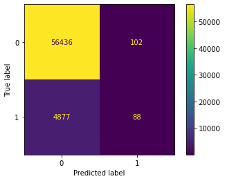

```python
# plot confusion matrix
plot_confusion_matrix(logistic_clf, x_test, y_test)
plt.show()
```

```python
# add accuracy score to results table
results.loc[0] = ['Logistic Regression', 'Merged Datasets', np.round(logistic_train_mean_accuracy_score*100, 2), np.round(logistic_test_score*100, 2), np.round(logistic_train_mean_roc_score*100, 2), np.round(logistic_test_roc_score*100, 2), logistic_grid_search.best_params_]

# show results
results
```

|  | model | Experiment | Train Accuracy | Test Accuracy | Train Area under ROC | Test Area under ROC | Best Parameters |
| --- | --- | --- | --- | --- | --- | --- | --- |
| 0 | Logistic Regression | Merged Datasets | NaN | 91.9 | NaN | 76.76 | {'logistic__C': 0.01, 'logistic__l1_ratio': 0.2} |

### Feature Importance

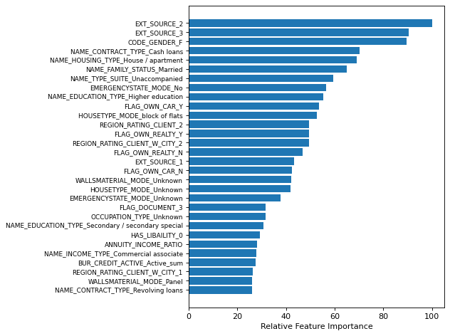

```
There are 69 features that have 0 importance.
```

```python
# plot the feature importance
lr_feature_importance_plot(clf=logistic_clf, names=column_names, n=30)
```

## Random Forest

```python
# fit best estimator on entire training data
rf_clf = rf_grid_search.best_estimator_.fit(x_train, y_train)

# generate predictions on test data
rf_predictions = rf_clf.predict(x_test)

# calculate score on test predictions
rf_test_score = accuracy_score(y_test, rf_predictions)

# calculate roc_auc score on test predictions
rf_test_roc_score = roc_auc_score(y_test, rf_clf.predict_proba(x_test)[:, 1])

# calculate classification report on test predictions
rf_test_classification_report = classification_report(y_test, rf_predictions)

# calculate confusion matrix on test predictions
rf_test_confusion_matrix = confusion_matrix(y_test, rf_predictions)
```

```python
# display the classification report
print(rf_test_classification_report)
```

```
              precision    recall  f1-score   support

           0       0.92      1.00      0.96     56538
           1       0.00      0.00      0.00      4965

    accuracy                           0.92     61503
   macro avg       0.46      0.50      0.48     61503
weighted avg       0.85      0.92      0.88     61503
```

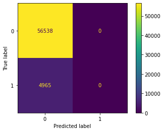

```python
# plot confusion matrix
plot_confusion_matrix(rf_clf, x_test, y_test)
plt.show()
```

```python
# add accuracy score to results table
results.loc[1] = ['Random Forest', 'Merged Datasets', np.round(rf_train_mean_accuracy_score*100, 2), np.round(rf_test_score*100, 2), np.round(rf_train_mean_roc_score*100, 2), np.round(rf_test_roc_score*100, 2), rf_grid_search.best_params_]

# show results
results
```

|  | model | Experiment | Train Accuracy | Test Accuracy | Train Area under ROC | Test Area under ROC | Best Parameters |
| --- | --- | --- | --- | --- | --- | --- | --- |
| 0 | Logistic Regression | Merged Datasets | NaN | 91.90 | NaN | 76.76 | {'logistic__C': 0.01, 'logistic__l1_ratio': 0.2} |
| 1 | Random Forest | Merged Datasets | NaN | 91.93 | NaN | 73.58 | {'rf__max_depth': 9, 'rf__max_features': 10, '... |

### Feature Importance

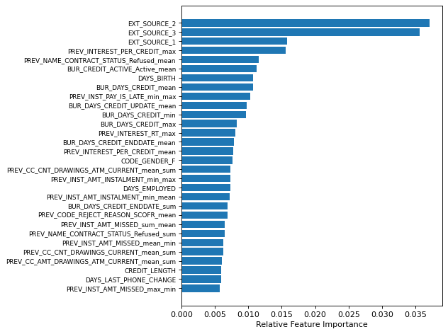

```
There are 160 features that have 0 importance.
```

```python
# plot feature importance
tree_feature_importance_plot(clf=rf_clf, step_name='rf', names=column_names, n=30)
```

## XGBoost

```python
# fit best estimator on entire training data
xgb_clf = xgb_grid_search.best_estimator_.fit(x_train, y_train)

# generate predictions on test data
xgb_predictions = xgb_clf.predict(x_test)

# calculate score on test predictions
xgb_test_score = accuracy_score(y_test, xgb_predictions)

# calculate roc_auc score on test predictions
xgb_test_roc_score = roc_auc_score(y_test, xgb_clf.predict_proba(x_test)[:, 1])

# calculate classification report on test predictions
xgb_test_classification_report = classification_report(y_test, xgb_predictions)

# calculate confusion matrix on test predictions
xgb_test_confusion_matrix = confusion_matrix(y_test, xgb_predictions)
```

```
[19:19:57] WARNING: C:/Users/Administrator/workspace/xgboost-win64_release_1.4.0/src/learner.cc:1095: Starting in XGBoost 1.3.0, the default evaluation metric used with the objective 'binary:logistic' was changed from 'error' to 'logloss'. Explicitly set eval_metric if you'd like to restore the old …
```

```python
# display the classification report
print(xgb_test_classification_report)
```

```
              precision    recall  f1-score   support

           0       0.92      1.00      0.96     56538
           1       0.62      0.02      0.04      4965

    accuracy                           0.92     61503
   macro avg       0.77      0.51      0.50     61503
weighted avg       0.90      0.92      0.88     61503
```

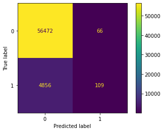

```python
# plot confusion matrix
plot_confusion_matrix(xgb_clf, x_test, y_test)
plt.show()
```

```python
# add accuracy score to results table
results.loc[2] = ['XGBoost', 'Merged Datasets', np.round(xgb_train_mean_accuracy_score*100, 2), np.round(xgb_test_score*100, 2), np.round(xgb_train_mean_roc_score*100, 2), np.round(xgb_test_roc_score*100, 2), xgb_grid_search.best_params_]

# show results
results
```

|  | model | Experiment | Train Accuracy | Test Accuracy | Train Area under ROC | Test Area under ROC | Best Parameters |
| --- | --- | --- | --- | --- | --- | --- | --- |
| 0 | Logistic Regression | Merged Datasets | NaN | 91.90 | NaN | 76.76 | {'logistic__C': 0.01, 'logistic__l1_ratio': 0.2} |
| 1 | Random Forest | Merged Datasets | NaN | 91.93 | NaN | 73.58 | {'rf__max_depth': 9, 'rf__max_features': 10, '... |
| 2 | XGBoost | Merged Datasets | NaN | 92.00 | NaN | 78.40 | {'xgb__colsample_bytree': 0.1, 'xgb__learning_... |

### Feature Importance

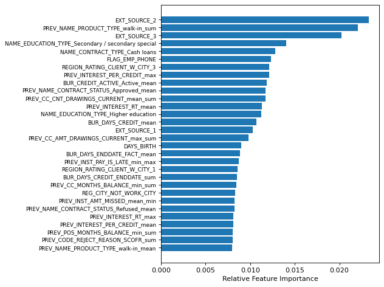

```
There are 509 features that have 0 importance.
```

```python
# plot feature importance
tree_feature_importance_plot(clf=xgb_clf, step_name='xgb', names=column_names, n=30)
```

```python
# temp time check - remove before submission
print("Start time is ", begin_time)
print("End time is ", datetime.datetime.now())
print("Run time is ", datetime.datetime.now() - begin_time)
```

```
Start time is  2021-04-20 17:20:02.208440
End time is  2021-04-20 19:20:47.134721
Run time is  2:00:44.926281
```